# Analisis mortalidad por causas 9

Federico Tricarico

2025-08-11

## 1 Intro

Analisis de la mortalidad por causas a nivel departamental.  
Se crea un set de datos nuevo, en CSV que contenga las regiones y el total nacional.  
Se calcula la tasa estandarizada por metodo indirecto(directo), y se analiza.

### 1.1 Data

```r
data_mort <- readRDS("data_salidas/data_mortalidad_deptos.rds")
```

```r
#labels

label_anios <- c("2005-2007", "2008-2010", "2011-2013", "2014-2016", "2017-2019")
anios <- c(2006, 2009, 2012, 2015, 2018)
# --
#
# mutate(
#     gedad = recode(
#       gedad,
#       "Menor de 24" = "e24_",
#       "25 a 69" = "e25_",
#       "70 y mas" = "e70_"
#     ),
#     sexo = recode(
#       sexo,
#       "Varón" = 1,
#       "Mujer" = 2
#     ),
#     grupo_oms = recode(
#       grupo_oms,
#       "Condiciones transmisibles, maternas, perinatales y nutricionales" = "trans",
#       "Enfermedades no transmisibles" = "notrans",
#       "Enfermedades mal definidas" = "maldef",
#       "Lesiones" = "lesi"
#     )
```

### 1.2 Geodata

Se importan los datos geograficos.

```r
geo_depto <- read_sf("data_geo/departamentos_geom_corr.gpkg")
geo_prov <- read_sf("data_geo/provincias.gpkg")
```

### 1.3 Manipulacion de datos

Crear un dataset de poblacion provincial, naciona, y regional? calcular tasas (razones) provincial, regional.

para producir grafico que muestre para cada gedad y causa, la tasa nacional, la regional, las provinciales y la de los deptos.

```r
data_mort
```

```
## # A tibble: 86,015 × 8
##    gedad  sexo geocodigo label          anio grupo_oms casos   pob
##    <ord> <dbl> <chr>     <chr>         <dbl> <chr>     <int> <dbl>
##  1 e70_      1 14154     Sobremonte     2003 notrans      75   140
##  2 e70_      2 42091     Limay Mahuida  2003 notrans       2     4
##  3 e70_      1 78042     Magallanes     2003 notrans      71   153
##  4 e70_      1 42063     Chical Co      2003 notrans      11    27
##  5 e70_      1 14154     Sobremonte     2009 notrans      63   157
##  6 e70_      1 6770      San Pedro      2003 notrans     593  1508
##  7 e70_      1 10014     Ancasti        2003 notrans      28    73
##  8 e70_      1 6070      Baradero       2003 notrans     364   960
##  9 e70_      1 30042     Feliciano      2003 notrans      92   245
## 10 e70_      1 10077     Paclín         2003 notrans      43   116
## # ℹ 86,005 more rows
```

### 1.4 Total nacional

```r
vars_agg_nac <- c("anio", "sexo", "gedad", "grupo_oms")

data_mort |>
  group_by_at(vars_agg_nac) |>
  reframe(
    casos = sum(casos),
    pob = sum(pob)
  ) |>
  mutate(
    rm = round(casos / pob, 10),
    geocodigo = NA,
    code_prov = as.character(1),
    label = "Total pais",
    level = 1
  ) -> data_mort_nac

head(data_mort_nac)
```

```
## # A tibble: 6 × 11
##    anio  sexo gedad grupo_oms casos     pob       rm geocodigo code_prov label
##   <dbl> <dbl> <ord> <chr>     <int>   <dbl>    <dbl> <lgl>     <chr>     <chr>
## 1  2003     1 e24_  lesi      15979 8475101 0.00189  NA        1         Total …
## 2  2003     1 e24_  maldef     1616 8475101 0.000191 NA        1         Total …
## 3  2003     1 e24_  notrans   13646 8475101 0.00161  NA        1         Total …
## 4  2003     1 e24_  trans     17557 8475101 0.00207  NA        1         Total …
## 5  2003     1 e25_  lesi      31129 8615567 0.00361  NA        1         Total …
## 6  2003     1 e25_  maldef    16730 8615567 0.00194  NA        1         Total …
## # ℹ 1 more variable: level <dbl>
```

### 1.5 Total regional

```r
regiones <- data.frame(
  code_prov = as.character(c(90, 10, 46, 86, 38, 66,
                34, 22,18, 54,
                82, 30, 6, 42, 14, 2,
                74, 70, 50,
                26,78,62,58,94)),
  code_reg = as.character(c(1001,1001,1001,1001,1001,1001,
               1002,1002,1002,1002,
               1003,1003,1003,1003,1003,1003,
               1004,1004,1004,
               1005,1005,1005,1005,1005)),
  region = c("NOA","NOA","NOA","NOA","NOA","NOA",
             "NEA", "NEA","NEA","NEA",
             "CENTRO","CENTRO","CENTRO","CENTRO","CENTRO", "CENTRO",
             "CUYO","CUYO","CUYO",
             "PATAGONIA","PATAGONIA","PATAGONIA","PATAGONIA","PATAGONIA"))
# regiones$code_prov <- as.character(regiones$code_prov)
```

```r
vars_agg_reg = c("anio", "sexo", "gedad", "grupo_oms", "code_reg", "region")

data_mort |>
  mutate(
    code_prov = if_else(
      nchar(geocodigo)==4,
      substr(geocodigo, 1, 1),
      substr(geocodigo, 1, 2)
    )) |>
  left_join(regiones, by=c("code_prov")) |>
  group_by_at(vars_agg_reg) |>
  reframe(
    casos = sum(casos),
    pob = sum(pob)
  ) |>
  mutate(
    rm = round(casos / pob, 7),
    geocodigo = NA,
    code_prov = code_reg,
    label = region,
    level = 2
  ) |>
  select(anio, sexo, gedad, grupo_oms, casos, pob, rm, geocodigo, code_prov, label, level)-> data_mort_reg

head(data_mort_reg)
```

```
## # A tibble: 6 × 11
##    anio  sexo gedad grupo_oms casos     pob       rm geocodigo code_prov label
##   <dbl> <dbl> <ord> <chr>     <int>   <dbl>    <dbl> <lgl>     <chr>     <chr>
## 1  2003     1 e24_  lesi       2025 1199433 0.00169  NA        1001      NOA
## 2  2003     1 e24_  lesi       1680  938945 0.00179  NA        1002      NEA
## 3  2003     1 e24_  lesi      10089 5265389 0.00192  NA        1003      CENTRO
## 4  2003     1 e24_  lesi       1303  625208 0.00208  NA        1004      CUYO
## 5  2003     1 e24_  lesi        882  446126 0.00198  NA        1005      PATAGO…
## 6  2003     1 e24_  maldef      338 1199433 0.000282 NA        1001      NOA
## # ℹ 1 more variable: level <dbl>
```

### 1.6 Total provincial

```r
lista_provs <- read.csv2("~/GitHub/dinamica_mortalidad/data_geo/provincia_labels.csv")
lista_provs$code_prov <- as.character(lista_provs$geocod)
```

```r
vars_agg_provs = c("anio", "sexo", "gedad", "grupo_oms", "code_prov", "label")

data_mort |>
  mutate(
    code_prov = if_else(
      nchar(geocodigo)==4,
      substr(geocodigo, 1, 1),
      substr(geocodigo, 1, 2)
    ),
    label = lista_provs$name_simp[match(code_prov, lista_provs$code_prov)]
    ) |>
  group_by_at(vars_agg_provs) |>
  reframe(
    casos = sum(casos),
    pob = sum(pob)
  ) |>
  mutate(
    rm = round(casos / pob, 10),
    geocodigo = NA,
    label = label,
    level = 3
  ) |>
  relocate(5:6, .after = geocodigo)-> data_mort_prov

head(data_mort_prov)
```

```
## # A tibble: 6 × 11
##    anio  sexo gedad grupo_oms casos    pob      rm geocodigo code_prov label
##   <dbl> <dbl> <ord> <chr>     <int>  <dbl>   <dbl> <lgl>     <chr>     <chr>
## 1  2003     1 e24_  lesi        133  88700 0.00150 NA        10        Catamarca
## 2  2003     1 e24_  lesi       1150 687229 0.00167 NA        14        Córdoba
## 3  2003     1 e24_  lesi        436 247664 0.00176 NA        18        Corrient…
## 4  2003     1 e24_  lesi        598 440127 0.00136 NA        2         CABA
## 5  2003     1 e24_  lesi        540 273570 0.00197 NA        22        Chaco
## 6  2003     1 e24_  lesi        243 106215 0.00229 NA        26        Chubut
## # ℹ 1 more variable: level <dbl>
```

```r
data_mort |>
  mutate(
    rm = round(casos / pob, 10),
    code_prov = if_else(
      nchar(geocodigo)==4,
      substr(geocodigo, 1, 1),
      substr(geocodigo, 1, 2)),
    level = 4
  ) |>
  select(anio, sexo, gedad, grupo_oms, casos, pob, rm, geocodigo, code_prov, label, level) |>
  bind_rows(data_mort_reg, data_mort_nac, data_mort_prov)-> dataset_mort

head(dataset_mort)
```

```
## # A tibble: 6 × 11
##    anio  sexo gedad grupo_oms casos   pob    rm geocodigo code_prov label  level
##   <dbl> <dbl> <ord> <chr>     <int> <dbl> <dbl> <chr>     <chr>     <chr>  <dbl>
## 1  2003     1 e70_  notrans      75   140 0.536 14154     14        Sobre…     4
## 2  2003     2 e70_  notrans       2     4 0.5   42091     42        Limay…     4
## 3  2003     1 e70_  notrans      71   153 0.464 78042     78        Magal…     4
## 4  2003     1 e70_  notrans      11    27 0.407 42063     42        Chica…     4
## 5  2009     1 e70_  notrans      63   157 0.401 14154     14        Sobre…     4
## 6  2003     1 e70_  notrans     593  1508 0.393 6770      6         San P…     4
```

```r
glimpse(dataset_mort)
```

```
## Rows: 91,055
## Columns: 11
## $ anio      <dbl> 2003, 2003, 2003, 2003, 2009, 2003, 2003, 2003, 2003, 2003, …
## $ sexo      <dbl> 1, 2, 1, 1, 1, 1, 1, 1, 1, 1, 1, 1, 1, 1, 2, 1, 1, 1, 1, 1, …
## $ gedad     <ord> e70_, e70_, e70_, e70_, e70_, e70_, e70_, e70_, e70_, e70_, …
## $ grupo_oms <chr> "notrans", "notrans", "notrans", "notrans", "notrans", "notr…
## $ casos     <int> 75, 2, 71, 11, 63, 593, 28, 364, 92, 43, 60, 179, 177, 128, …
## $ pob       <dbl> 140, 4, 153, 27, 157, 1508, 73, 960, 245, 116, 165, 494, 490…
## $ rm        <dbl> 0.5357143, 0.5000000, 0.4640523, 0.4074074, 0.4012739, 0.393…
## $ geocodigo <chr> "14154", "42091", "78042", "42063", "14154", "6770", "10014"…
## $ code_prov <chr> "14", "42", "78", "42", "14", "6", "10", "6", "30", "10", "5…
## $ label     <chr> "Sobremonte", "Limay Mahuida", "Magallanes", "Chical Co", "S…
## $ level     <dbl> 4, 4, 4, 4, 4, 4, 4, 4, 4, 4, 4, 4, 4, 4, 4, 4, 4, 4, 4, 4, …
```

```r
# Se graba un set de datos
# write.csv(dataset_mort, "data_salidas/dataset_mort.csv", row.names = FALSE, fileEncoding = "latin1")
```

### 1.7 Estandarizacion

Se calcula una Mortalidad estandar por edad y sexo segun causa para el total nacional como representativo de la media (se advierte sesgo por diferencias relativas en tamaño de AMBA y grandes ciudades contra Norte y Patagonia). Luego, obtenemos las Muertes esperadas $\text {M}_{e}$ que resulta de multiplicar la poblacion del departamento $\text {pob}_{i}$ segun edad y sexo, por la Razon de mortalidad calculada para el total nacional ${r}_{e}$.

$$\text {M}_{e} = {pob}_{i} \times {r}_{e}$$

Luego, se comparan las Muertes observadas con aquellas Muertes esperadas, mediante una Razon simple,o Razon de Mortalidad Estandar

$$\text {RMS} = \frac{M_{o}}{M_{e}}$$

Estas Razones de mortalidad de los trienios, pueden usarse para observar si en cada combo (edad, sexo y residencia) la mortalidad es mayor o menor a la que se esperaría en relacion a Razon de mortalidad nacional. Esto es, al multiplicar la poblacion por edad y sexo y causa de cada departamento, por la Razon de mortalidad nacional, se obtiene el numero defunciones esperadas. Al dividir las defunciones observadas por las esperadas, tendremos un indicador del ” *nivel de la mortalidad* “. Pero es un indicador de **nivel relativo**, es decir, indica sólo si la razon de mortalidad observada es mayor ( `RMS >> 1` ) menor (`RMS << 1`) o igual (`RMS ≈ 1`) a la que se esperaria tenga si su poblacion estaria sometida al patron de mortalidad nacional.

Luego de analizar la distirbucion de la SMR, se exploran metodos para suavizar el indicador, a partir de indicadores globales, como la media nacional o de todo el conjunto de datos, o locales, estimados para cada unidad de area a partir de los indicadores de areas vecinas.

Luego en capitulos siguientes, se podria modelar la distribucion espacial por departamento. Donde las relaciones de vecindad aportan *robustez al modelo*, al *agregar* informacion basado en la relaciones espaciales para cada caso, sobre todo en casos donde las frecuencias o distribucion son escasas ( borrowing strenght ).

#### 1.7.1 El estandar

Se procede a la agregacion del conjunto de datos a un total nacional, para estimar la mortalidad por causas para cada grupos de edad, sexo y trienio, estandar. o media nacional.

```r
data_mort_nac |>
  select(1:7) -> data_mort_nac

head(data_mort_nac)
```

```
## # A tibble: 6 × 7
##    anio  sexo gedad grupo_oms casos     pob       rm
##   <dbl> <dbl> <ord> <chr>     <int>   <dbl>    <dbl>
## 1  2003     1 e24_  lesi      15979 8475101 0.00189
## 2  2003     1 e24_  maldef     1616 8475101 0.000191
## 3  2003     1 e24_  notrans   13646 8475101 0.00161
## 4  2003     1 e24_  trans     17557 8475101 0.00207
## 5  2003     1 e25_  lesi      31129 8615567 0.00361
## 6  2003     1 e25_  maldef    16730 8615567 0.00194
```

Resumen de la distirbucion de eventos.

```r
summary(data_mort_nac$casos)
```

```
##    Min. 1st Qu.  Median    Mean 3rd Qu.    Max.
##     544    5984   12128   42181   31862  289765
```

Resumen de la distirbucion de poblacion

```r
summary(data_mort_nac$pob)
```

```
##     Min.  1st Qu.   Median     Mean  3rd Qu.     Max.
##   916385  1809387  8519815  6848803  9634378 12718809
```

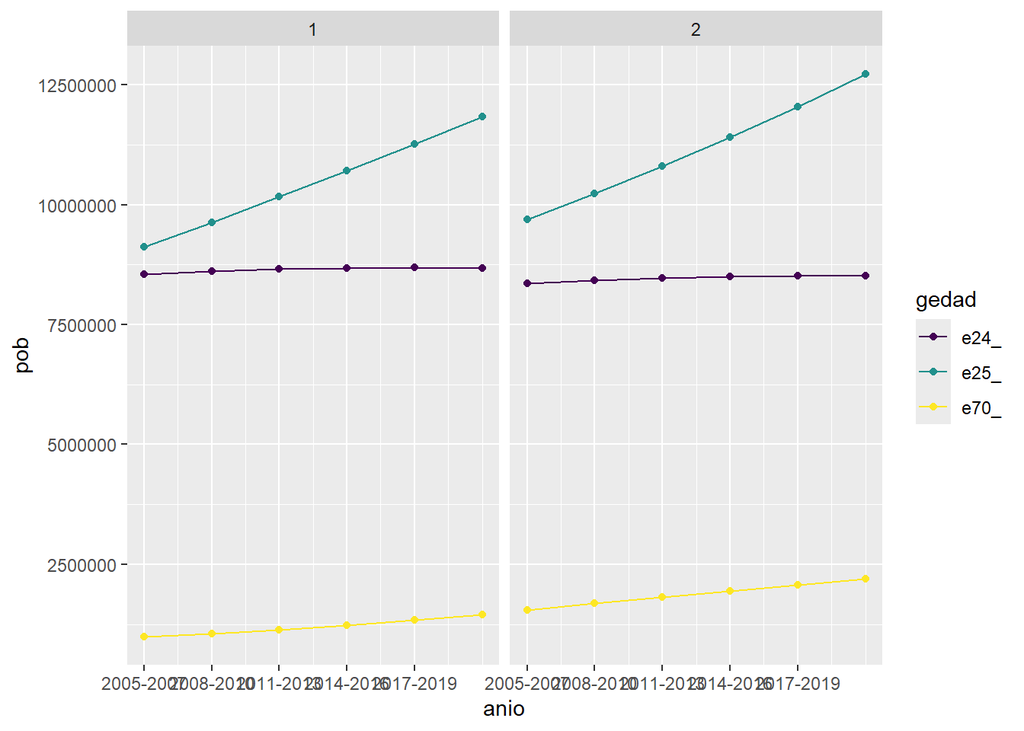

```r
data_mort_nac |>
  filter(anio != 2003) |>
  ggplot(aes(anio, pob, colour=gedad))+
  geom_point()+
  geom_line()+
  scale_x_continuous(breaks = anios, labels = label_anios)+
  facet_wrap(~sexo)
```

Razon de mortalidad estandar

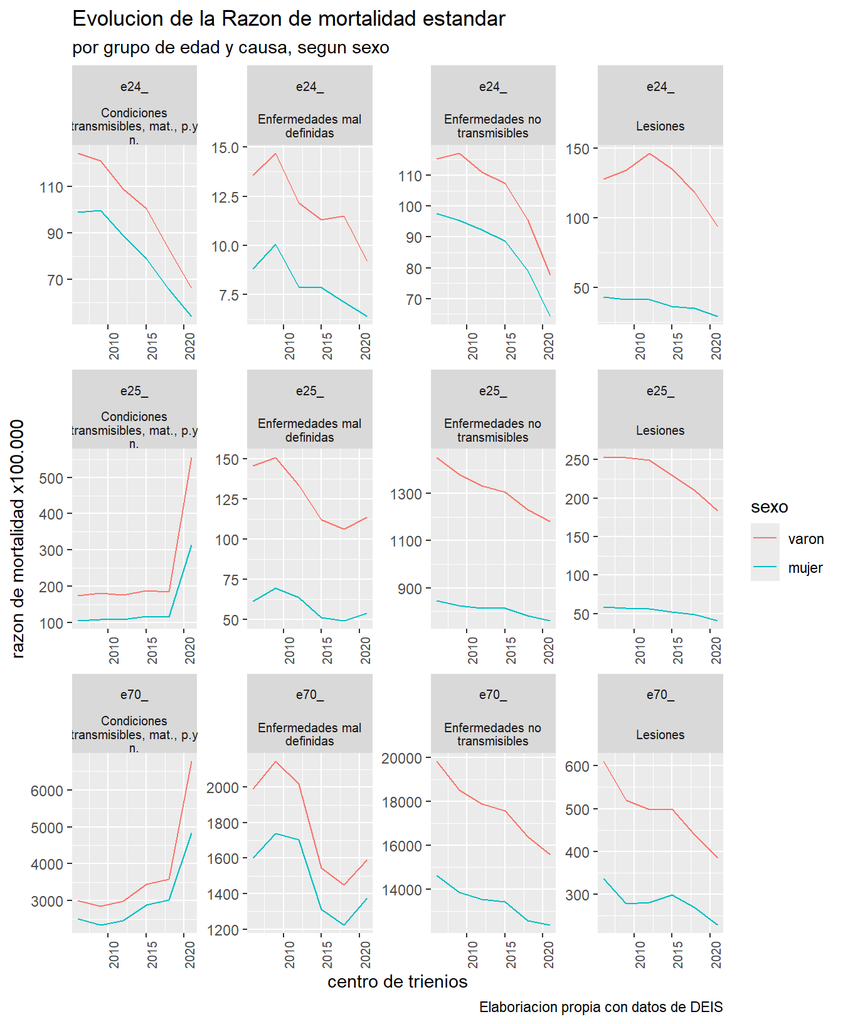

```r
data_mort_nac |>
  filter(anio != 2003) |>
  mutate(
    rmxm = rm * 100000,
    grupo_oms = recode(
      grupo_oms,
      "trans" = "Condiciones transmisibles, mat., p.y n.",
      "notrans" = "Enfermedades no transmisibles",
      "maldef" = "Enfermedades mal definidas",
      "lesi" = "Lesiones")
  ) |>
  ggplot(aes(anio, rmxm, colour=as.character(sexo)))+
  geom_line()+
  scale_color_discrete(labels = c("varon", "mujer"))+
  facet_wrap(~gedad~grupo_oms, scales="free", ncol=4, labeller = label_wrap_gen())+
  theme(
    axis.text.x = element_text(angle = 90, size = 7.5),
    strip.text = element_text(size=7.5, margin = margin())
  )+
  labs(
    title = "Evolucion de la Razon de mortalidad estandar",
    subtitle = "por grupo de edad y causa, segun sexo",
    color = "sexo",
    y= "razon de mortalidad x100.000",
    x = "centro de trienios",
    caption = "Elaboriacion propia con datos de DEIS"
  )
```

Dado que se tienen 10759 registros sin eventos.

Y al menos un caso, sin poblacion. (se ha eliminado un registro de defuncion de mayor de 70 en Antartida)

```r
  data_mort |>
  filter(pob==0 ) |>
  distinct()
```

```
## # A tibble: 55 × 8
##    gedad  sexo geocodigo label                anio grupo_oms casos   pob
##    <ord> <dbl> <chr>     <chr>               <dbl> <chr>     <int> <dbl>
##  1 e70_      2 94028     Antártida Argentina  2003 trans         0     0
##  2 e70_      2 94028     Antártida Argentina  2003 maldef        0     0
##  3 e70_      2 94028     Antártida Argentina  2003 notrans       0     0
##  4 e70_      2 94028     Antártida Argentina  2003 lesi          0     0
##  5 e70_      2 94028     Antártida Argentina  2006 trans         0     0
##  6 e70_      2 94028     Antártida Argentina  2006 maldef        0     0
##  7 e70_      2 94028     Antártida Argentina  2006 notrans       0     0
##  8 e70_      2 94028     Antártida Argentina  2006 lesi          0     0
##  9 e70_      2 94028     Antártida Argentina  2009 trans         0     0
## 10 e70_      2 94028     Antártida Argentina  2009 maldef        0     0
## # ℹ 45 more rows
```

Por tanto al momento de calcular las razones, esta se calcula para todos los casos donde existen casos y poblacion, de lo contrario se consigna 0.

```r
data_estandar <- data_mort_nac |>
  select(anio, sexo, gedad, grupo_oms, rm)
```

#### 1.7.2 La Razon de Mortalidad Estandar

```r
data_mort |>
  left_join(data_estandar, by=c("anio", "gedad", "sexo", "grupo_oms"), suffix = c("_loc", "_nac")) |>
  mutate(
    rm_loc = if_else(
    casos >0 & pob >0,
    round(casos / pob,10),
    0
    ),
    casos_esp = if_else(
      pob > 0,
      round(pob * rm, 2),
      NA
      ),
    smr = if_else(
      casos > 0,
      round(casos / casos_esp,2),
      NA
    ))-> data_mort_estandar

head(data_mort_estandar)
```

```
## # A tibble: 6 × 12
##   gedad  sexo geocodigo label  anio grupo_oms casos   pob    rm rm_loc casos_esp
##   <ord> <dbl> <chr>     <chr> <dbl> <chr>     <int> <dbl> <dbl>  <dbl>     <dbl>
## 1 e70_      1 14154     Sobr…  2003 notrans      75   140 0.278  0.536     39.0
## 2 e70_      2 42091     Lima…  2003 notrans       2     4 0.204  0.5        0.81
## 3 e70_      1 78042     Maga…  2003 notrans      71   153 0.278  0.464     42.6
## 4 e70_      1 42063     Chic…  2003 notrans      11    27 0.278  0.407      7.51
## 5 e70_      1 14154     Sobr…  2009 notrans      63   157 0.185  0.401     29.1
## 6 e70_      1 6770      San …  2003 notrans     593  1508 0.278  0.393    420.
## # ℹ 1 more variable: smr <dbl>
```

```r
data_mort_estandar<-data_mort_estandar |> filter(anio != 2003)
```

Resumen de la distribucion de la Razon local

```r
summary(data_mort_estandar$rm_loc)
```

```
##      Min.   1st Qu.    Median      Mean   3rd Qu.      Max.
## 0.0000000 0.0005238 0.0016642 0.0175031 0.0105624 0.4012739
```

Se observa que la minima es 0, y la maxima 0.40, es decir equivalente a una tasa de 40%, lo cual es excesivamente alta.

```r
data_mort_estandar |>
  slice_max(rm_loc, n=15)
```

```
## # A tibble: 16 × 12
##    gedad  sexo geocodigo label           anio grupo_oms casos   pob    rm rm_loc
##    <ord> <dbl> <chr>     <chr>          <dbl> <chr>     <int> <dbl> <dbl>  <dbl>
##  1 e70_      1 14154     Sobremonte      2009 notrans      63   157 0.185  0.401
##  2 e70_      1 14154     Sobremonte      2006 notrans      51   148 0.198  0.345
##  3 e70_      1 78042     Magallanes      2006 notrans      49   151 0.198  0.325
##  4 e70_      1 42091     Limay Mahuida   2018 notrans       6    19 0.164  0.316
##  5 e70_      1 22147     San Lorenzo     2006 notrans      76   245 0.198  0.310
##  6 e70_      1 78049     Río Chico       2015 notrans      27    91 0.176  0.297
##  7 e70_      1 86112     Mitre           2006 notrans      13    44 0.198  0.295
##  8 e70_      1 78042     Magallanes      2021 notrans      59   208 0.156  0.284
##  9 e70_      1 6161      Carmen de Are…  2006 notrans     122   441 0.198  0.277
## 10 e70_      1 6351      General Pinto   2006 notrans     102   372 0.198  0.274
## 11 e70_      1 6329      General Las H…  2006 notrans     103   377 0.198  0.273
## 12 e70_      2 14154     Sobremonte      2006 notrans      43   158 0.146  0.272
## 13 e70_      1 42126     Rancul          2006 notrans      73   270 0.198  0.270
## 14 e70_      2 46077     General Lamad…  2015 notrans      10    37 0.134  0.270
## 15 e70_      2 26063     Mártires        2006 notrans       5    19 0.146  0.263
## 16 e70_      2 26063     Mártires        2012 notrans       5    19 0.135  0.263
## # ℹ 2 more variables: casos_esp <dbl>, smr <dbl>
```

Si se observan los registros mas altos, se observa que se trata siempre de poblaciones pequeñas en el segmento de edad mayores de 70.

Resumen de la distribucion de la Razon de mortaliddad (Muertes observadas / Muertes esperadas)

```r
summary(data_mort_estandar$smr)
```

```
##    Min. 1st Qu.  Median    Mean 3rd Qu.    Max.    NA's
##   0.010   0.720   0.990   1.182   1.330  44.440    9572
```

Se observan los 10.759 (9572 sin contar el trienio de 2003) registros (para cada combinacion de edad x sexo x causa x año) donde no se registraron eventos, por tanto no se calcula la razon, dado que

$\frac {M_{o}}{0} = \text {Inf}$ cuando $\text M_{o} = 0 => NA$

```r
DT::datatable(

data_mort_estandar |>
  slice_max(smr, n=15),
caption = "N=15 con SMR mas alto"
)
```

|  | gedad | sexo | geocodigo | label | anio | grupo_oms | casos | pob | rm | rm_loc | casos_esp | smr |
| --- | --- | --- | --- | --- | --- | --- | --- | --- | --- | --- | --- | --- |
| 1 | e24_ | 1 | 38049 | Rinconada | 2006 | maldef | 4 | 672 | 0.0001357447 | 0.005952381 | 0.09 | 44.44 |
| 2 | e25_ | 2 | 42091 | Limay Mahuida | 2009 | lesi | 2 | 107 | 0.0005747552 | 0.0186915888 | 0.06 | 33.33 |
| 3 | e24_ | 2 | 46077 | General Lamadrid | 2015 | maldef | 1 | 402 | 7.86457e-05 | 0.0024875622 | 0.03 | 33.33 |
| 4 | e24_ | 2 | 38049 | Rinconada | 2018 | maldef | 1 | 465 | 7.12369e-05 | 0.0021505376 | 0.03 | 33.33 |
| 5 | e24_ | 2 | 46091 | General San Martín | 2021 | maldef | 2 | 1060 | 6.3859e-05 | 0.0018867925 | 0.07 | 28.57 |
| 6 | e24_ | 1 | 38077 | Santa Catalina | 2006 | maldef | 3 | 857 | 0.0001357447 | 0.0035005834 | 0.12 | 25 |
| 7 | e24_ | 2 | 46105 | Independencia | 2018 | maldef | 1 | 552 | 7.12369e-05 | 0.0018115942 | 0.04 | 25 |
| 8 | e24_ | 1 | 38077 | Santa Catalina | 2012 | maldef | 2 | 746 | 0.0001216545 | 0.0026809651 | 0.09 | 22.22 |
| 9 | e24_ | 2 | 42063 | Chical Co | 2012 | lesi | 3 | 334 | 0.0004123562 | 0.0089820359 | 0.14 | 21.43 |
| 10 | e70_ | 2 | 42091 | Limay Mahuida | 2018 | lesi | 1 | 18 | 0.0026913384 | 0.0555555556 | 0.05 | 20 |

[output cut: 7 more lines]

¿Quiere decir esto que la mortalidad por causas mal definidas en jovenes, o por lesiones, es en localidades menores a 1.000 habitantes, 20, 30, 40 o 50 veces mas alta que la esperada? No!

### 1.8 Distribucion de la RME

#### 1.8.1 Dist. Continua

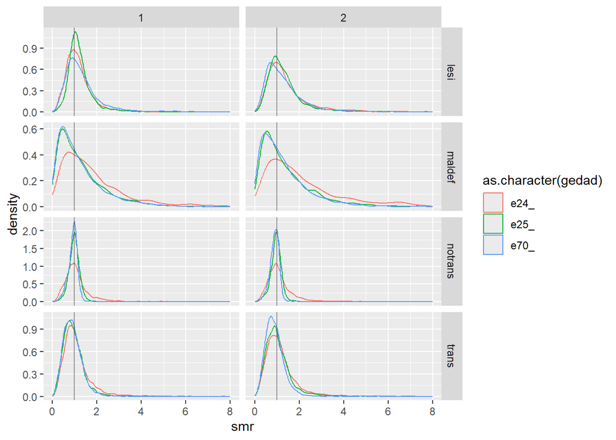

```r
data_mort_estandar |>
  ggplot(aes(smr, colour = as.character(gedad)))+
  geom_density()+
  geom_vline(xintercept = 1, linewidth = .5, colour = "grey20", alpha=.5)+
  scale_x_continuous(limits = c(0, 8))+
  # scale_x_log10()+
  facet_grid(grupo_oms~sexo, scales="free")
```

Se observa que aun existen las colas largas o pesadas en la distribucion, debido a que los casos extremos no se anulan en la estandarizacion y estimacion del riesgo relativo.

#### 1.8.2 Dist. Log

```r
data_mort_estandar |>
  mutate(
    grupo_oms = recode(
      grupo_oms,
      "trans" = "Condiciones trans, m,p y n.",
      "notrans" = "Enfermedades no transmisibles" ,
      "maldef"= "Enfermedades mal definidas",
      "lesi" = "Lesiones"),
    gedad= recode(
      gedad,
      "e24_" = "Menor de 24",
      "e25_" = "25 a 69",
      "e70_" = "70 y mas"
    ),
    gedad = factor(gedad, ordered = TRUE),
    sexo= recode(
      sexo,
      "1" = "Varon",
      "2" = "Mujer"
    ))->data_mort_estandar
```

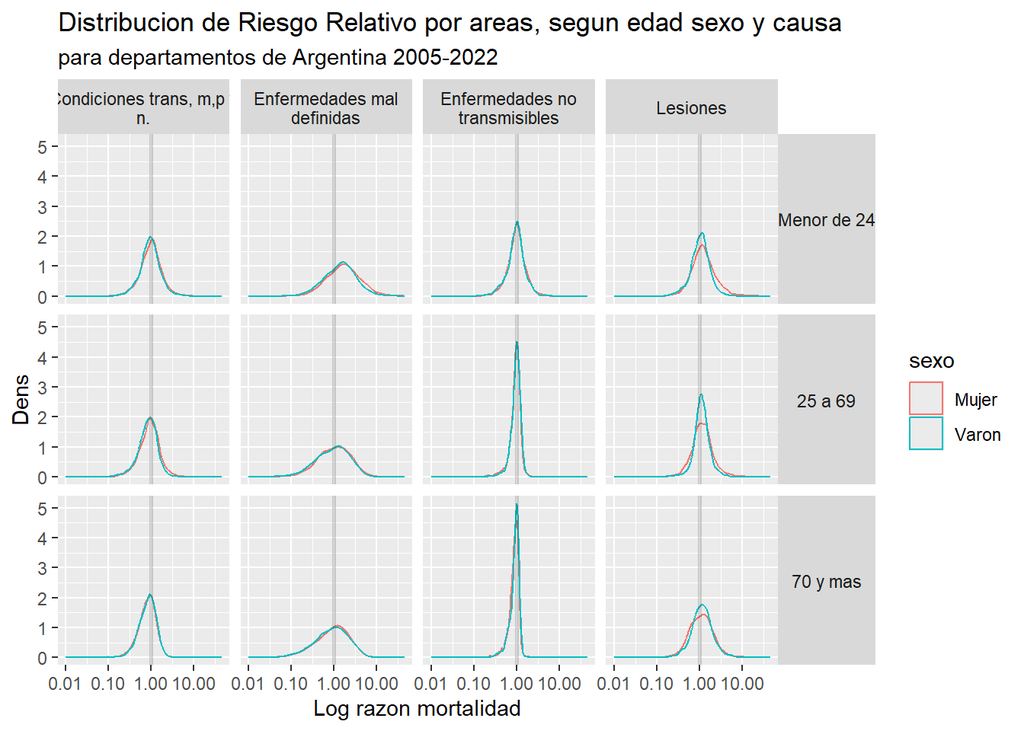

```r
data_mort_estandar |>
ggplot(aes(smr, colour = sexo))+
  geom_density()+
  geom_vline(xintercept = 1, linewidth = 1, colour = "grey20", alpha=.2)+
  scale_x_log10()+
  labs(
    x = "Log razon mortalidad",
    y = "Dens",
    title = "Distribucion de Riesgo Relativo por areas, segun edad sexo y causa",
    subtitle = "para departamentos de Argentina 2005-2022"
  )+
  facet_grid(gedad~grupo_oms, labeller = label_wrap_gen(multi_line = TRUE))+
  theme(
    strip.text.y = element_text(angle = 0, margin = margin())
  )
```

### 1.9 La SMR regional

```r
data_mort_estandar |>
  mutate(
    code_prov = if_else(
      nchar(geocodigo)==4,
      substr(geocodigo, 1, 1),
      substr(geocodigo, 1, 2)
    )) |>
  left_join(regiones, by=c("code_prov")) |>
  group_by(anio, sexo, gedad, grupo_oms, region) |>
  summarise(
    casos = sum(casos, na.rm = TRUE),
    casos_esp = sum(casos_esp, na.rm = TRUE),
    pob = sum(pob, na.rm = TRUE)
  ) |>
  ungroup() |>
  mutate(
    rmxm = casos / pob * 100000,
    smr = if_else(casos>0, casos / casos_esp, 0)
  ) -> data_mort_estandar_region
```

[output not shown]

```r
data_mort_estandar_region
```

```
## # A tibble: 720 × 10
##     anio sexo  gedad       grupo_oms  region casos casos_esp    pob   rmxm   smr
##    <dbl> <chr> <ord>       <chr>      <chr>  <int>     <dbl>  <dbl>  <dbl> <dbl>
##  1  2006 Mujer Menor de 24 Condicion… CENTRO  4463    5163.  5.21e6  85.6  0.864
##  2  2006 Mujer Menor de 24 Condicion… CUYO     600     609.  6.15e5  97.5  0.985
##  3  2006 Mujer Menor de 24 Condicion… NEA     1458     910.  9.19e5 159.   1.60
##  4  2006 Mujer Menor de 24 Condicion… NOA     1433    1165.  1.18e6 122.   1.23
##  5  2006 Mujer Menor de 24 Condicion… PATAG…   332     439.  4.43e5  74.9  0.757
##  6  2006 Mujer Menor de 24 Enfermeda… CENTRO   486     459.  5.21e6   9.32 1.06
##  7  2006 Mujer Menor de 24 Enfermeda… CUYO       8      54.2 6.15e5   1.30 0.148
##  8  2006 Mujer Menor de 24 Enfermeda… NEA       94      80.9 9.19e5  10.2  1.16
##  9  2006 Mujer Menor de 24 Enfermeda… NOA      130     104.  1.18e6  11.1  1.26
## 10  2006 Mujer Menor de 24 Enfermeda… PATAG…    19      39.0 4.43e5   4.29 0.487
## # ℹ 710 more rows
```

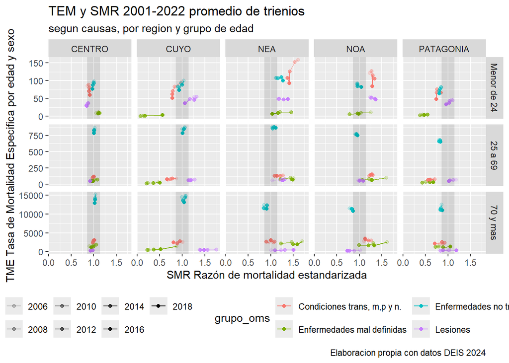

```r
data_mort_estandar_region |>
  filter(sexo == "Mujer", !anio %in% c(2003, 2021)) |>
  ggplot(aes(smr, rmxm, color= grupo_oms, alpha = anio))+
  geom_point(position = "jitter", size = 1.5)+
  geom_line(aes(smr, rmxm,color= grupo_oms, alpha = anio))+
  geom_vline(xintercept = 1, linewidth = 6, alpha = .1)+
  facet_grid(gedad~region, scale="free_y")+
  theme(legend.position = "bottom")+
  scale_alpha_continuous(range = c(0.2, 0.99))+
  guides(color=guide_legend(nrow = 2))+
  labs(
    title="TEM y SMR 2001-2022 promedio de trienios",
    subtitle="segun causas, por region y grupo de edad",
    y= "TME Tasa de Mortalidad Especifica por edad y sexo",
    x= "SMR Razón de mortalidad estandarizada",
    caption = "Elaboracion propia con datos DEIS 2024"
  )
```

Se observa que el estandar es en los hechos la region centro. sesgando las comparaciones, antes que una comparacion inter-regional, se obtiene una comparacion de las regiones en relacion a la region centro.

### 1.10 La SMR provincial

```r
data_mort_estandar |>
  mutate(
    code_prov = if_else(
      nchar(geocodigo)==4,
      substr(geocodigo, 1, 1),
      substr(geocodigo, 1, 2)
    ),
    prov = lista_provs$name_simp[match(code_prov, lista_provs$code_prov)]
    ) |>
  group_by(anio, sexo, gedad, grupo_oms, code_prov, prov) |>
  summarise(
    casos = sum(casos, na.rm = TRUE),
    casos_esp = sum(casos_esp, na.rm = TRUE),
    pob = sum(pob, na.rm = TRUE)
  ) |>
  ungroup() |>
  mutate(
    rmxm = casos / pob * 100000,
    smr = if_else(casos>0, casos / casos_esp, 0)
  ) -> data_mort_estandar_prov
```

[output not shown]

```r
head(data_mort_estandar_prov)
```

```
## # A tibble: 6 × 11
##    anio sexo  gedad grupo_oms code_prov prov  casos casos_esp    pob  rmxm   smr
##   <dbl> <chr> <ord> <chr>     <chr>     <chr> <int>     <dbl>  <dbl> <dbl> <dbl>
## 1  2006 Mujer Meno… Condicio… 10        Cata…   101      85.7  86552 117.  1.18
## 2  2006 Mujer Meno… Condicio… 14        Córd…   504     665.  671648  75.0 0.758
## 3  2006 Mujer Meno… Condicio… 18        Corr…   317     239.  240917 132.  1.33
## 4  2006 Mujer Meno… Condicio… 2         CABA    304     432   436096  69.7 0.704
## 5  2006 Mujer Meno… Condicio… 22        Chaco   431     263.  265115 163.  1.64
## 6  2006 Mujer Meno… Condicio… 26        Chub…    82     106.  106825  76.8 0.775
```

```r
summary(data_mort_estandar_prov$smr)
```

```
##    Min. 1st Qu.  Median    Mean 3rd Qu.    Max.
##  0.0000  0.7958  0.9708  1.0122  1.1865  3.3253
```

#### 1.10.1 Mapa provincial

Se observa la distirbucion de la SMR por causas por provincia.

```r
data_mort_estandar_prov |>
  filter(anio == 2018)->geo_data_mort_estandar_prov
```

```r
geo_data_mort_estandar_prov |>
  merge(geo_prov, by.x = "code_prov", by.y = "prov")-> geo_data_mort_estandar_prov

geo_data_mort_estandar_prov <- st_as_sf(geo_data_mort_estandar_prov)
```

##### 1.10.1.1 Mapas por causas

###### 1.10.1.1.1 Menores de 24

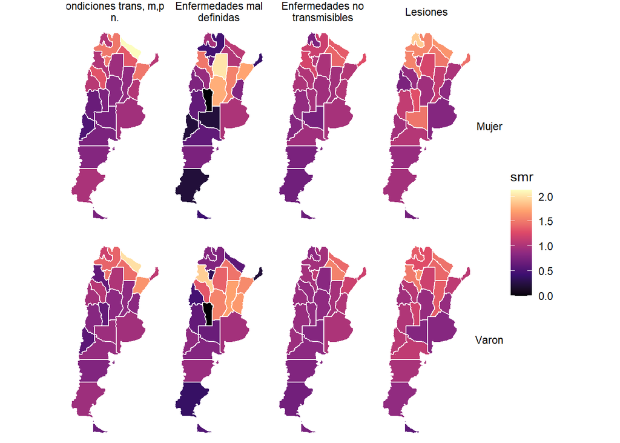

```r
geo_data_mort_estandar_prov |>
  filter(gedad == "Menor de 24") |>
  ggplot()+
  geom_sf(aes(fill=smr), color="white", lwd=.5)+
  scale_fill_viridis_c(option = "A")+
  facet_grid(sexo~grupo_oms, labeller = label_wrap_gen(multi_line = TRUE))+
  theme_void()
```

###### 1.10.1.1.2 de 25 a 69

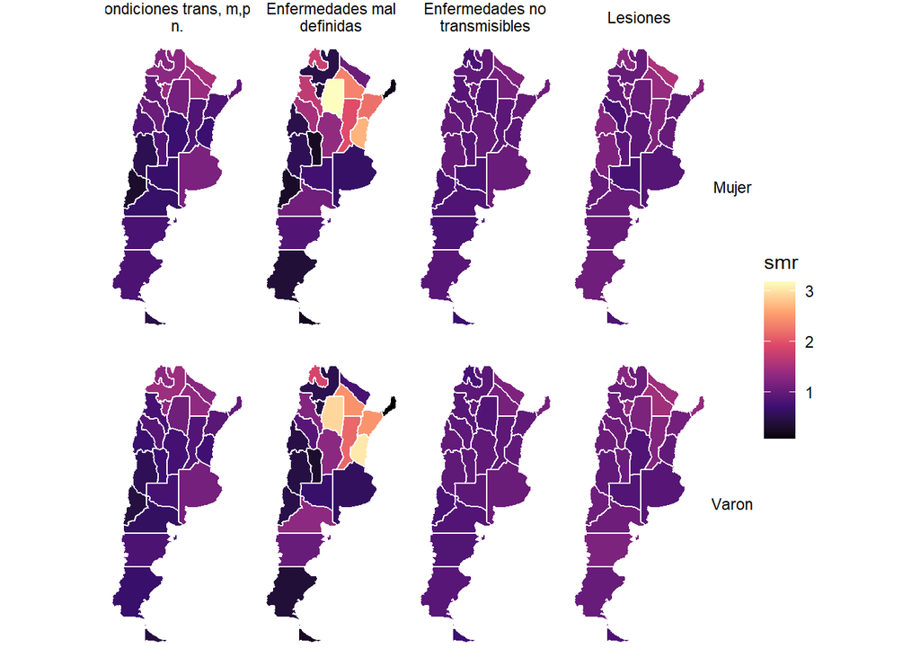

```r
geo_data_mort_estandar_prov |>
  filter(gedad == "25 a 69") |>
  ggplot()+
  geom_sf(aes(fill=smr), color="white", lwd=.5)+
  scale_fill_viridis_c(option = "A")+
  facet_grid(sexo~grupo_oms, labeller = label_wrap_gen(multi_line = TRUE))+
  theme_void()
```

###### 1.10.1.1.3 de 70 y mas

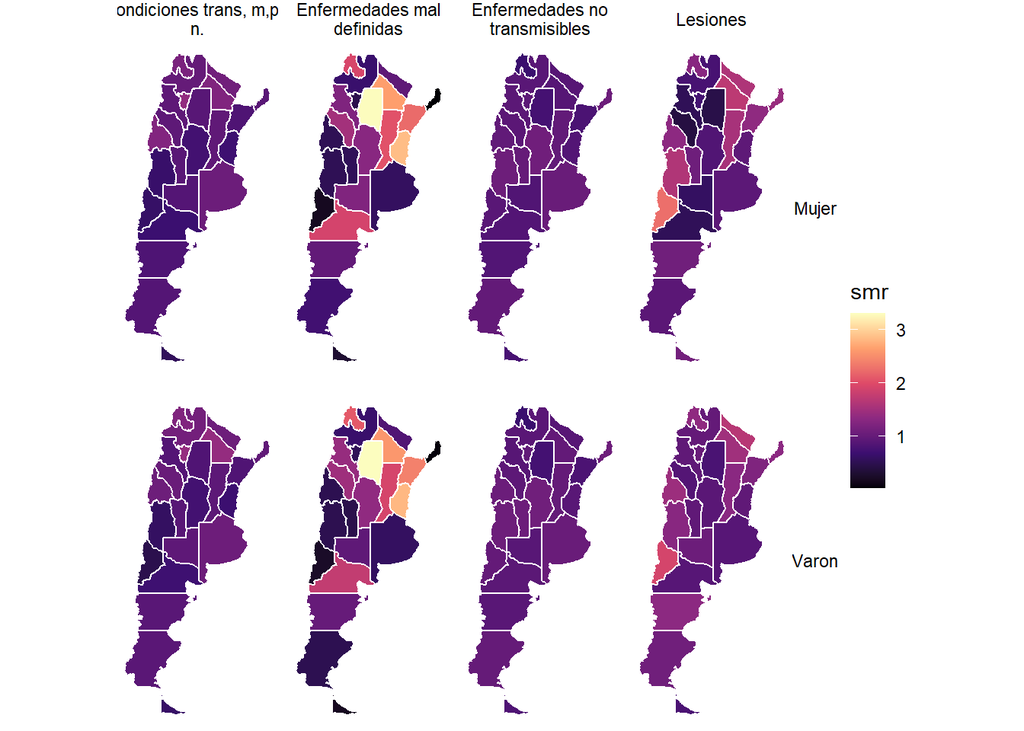

```r
geo_data_mort_estandar_prov |>
  filter(gedad == "70 y mas") |>
  ggplot()+
  geom_sf(aes(fill=smr), color="white", lwd=.5)+
  scale_fill_viridis_c(option = "A")+
  facet_grid(sexo~grupo_oms, labeller = label_wrap_gen(multi_line = TRUE))+
  theme_void()
```

### 1.11 Head-Tail

```r
smr_vector <- data_mort_estandar |>
  filter(grupo_oms == "Lesiones", gedad == "25 a 69", sexo == "Varon") |>
  distinct(smr)
```

```r
head(smr_vector)
## # A tibble: 6 × 1
##     smr
##   <dbl>
## 1  7.02
## 2  5.41
## 3  5.66
## 4  4.76
## 5  4.65
## 6  4.62
summary(smr_vector)
##       smr
##  Min.   :0.1100
##  1st Qu.:0.9325
##  Median :1.6850
##  Mean   :1.8197
##  3rd Qu.:2.4875
##  Max.   :7.0200
##  NA's   :1
```

```r
paleta <- c("wheat1", "wheat2", "red3")
```

```r
# Minimum: single break
print(classInt::classIntervals(smr_vector$smr, style = "headtails", thr = 0))
```

```
## style: headtails
## [0.11,1.819702) [1.819702,7.02]
##             164             138
```

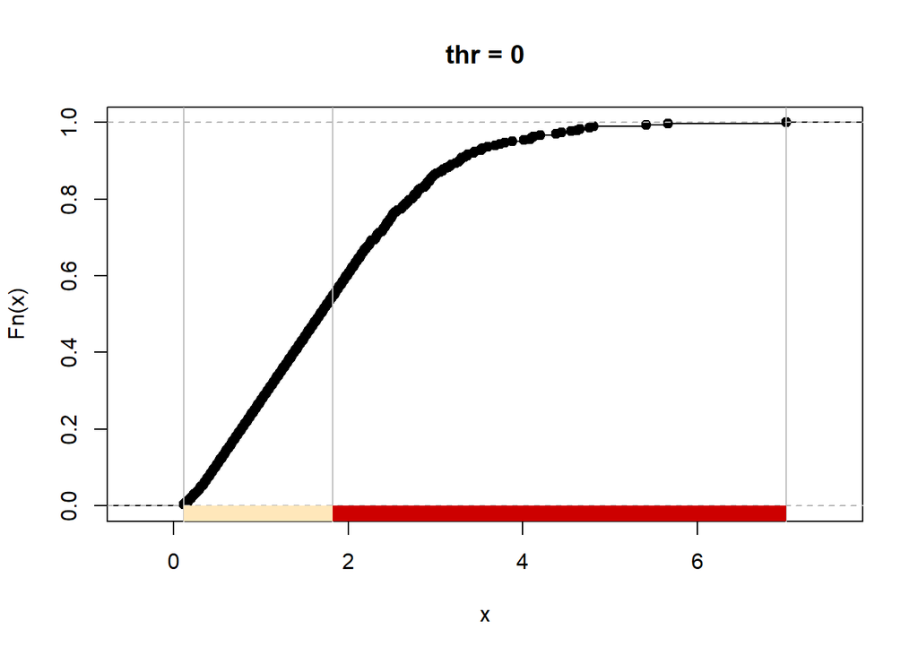

```r
plot(
  classInt::classIntervals(smr_vector$smr, style = "headtails", thr = 0),
  pal = paleta,
  main = "thr = 0"
)
```

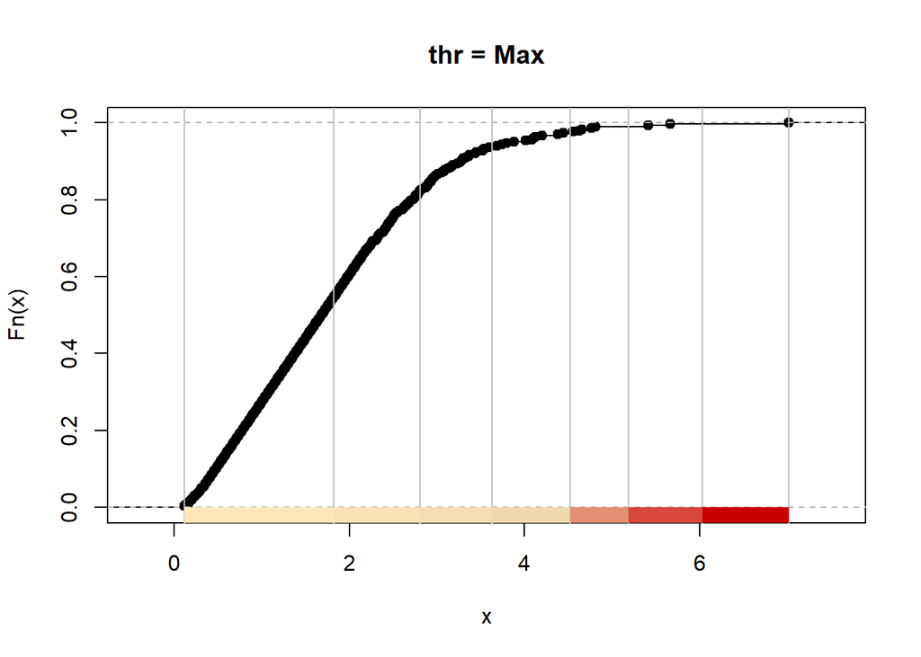

```r
plot(
  classInt::classIntervals(smr_vector$smr, style = "headtails", thr = 1),
  pal = paleta,
  main = "thr = Max"
)
```

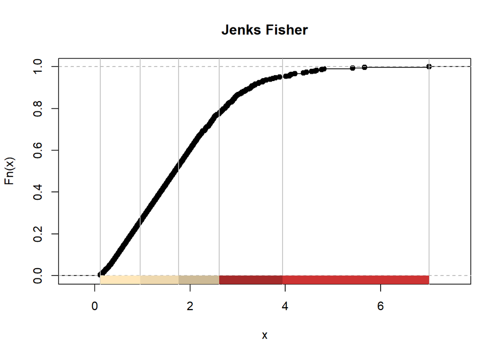

```r
paleta2 <- c("wheat1", "wheat2","wheat3", "brown", "brown3")
plot(
  classInt::classIntervals(smr_vector$smr, style = "fisher", n = 5),
  pal = paleta2,
  main = "Jenks Fisher"
)
```

### 1.12 Mapa SMR

```r
data_mort_estandar |>
  filter(anio == 2018)->geo_data_mort_estandar
```

```r
geo_data_mort_estandar |>
  merge(geo_depto, by.x = "geocodigo", by.y = "DEPTO_LINK")-> geo_data_mort_estandar
geo_data_mort_estandar <- st_as_sf(geo_data_mort_estandar)
```

```r
geo_prov <- st_as_sf(geo_prov)
```

#### 1.12.1 Mapas

```r
class(geo_data_mort_estandar)
```

```
## [1] "sf"         "data.frame"
```

```r
str(geo_data_mort_estandar)
```

```
## Classes 'sf' and 'data.frame':   12264 obs. of  16 variables:
##  $ geocodigo: chr  "10007" "10007" "10007" "10007" ...
##  $ gedad    : Ord.factor w/ 3 levels "Menor de 24"<..: 3 1 3 2 2 3 1 1 3 2 ...
##  $ sexo     : chr  "Mujer" "Mujer" "Varon" "Mujer" ...
##  $ label    : chr  "Ambato" "Ambato" "Ambato" "Ambato" ...
##  $ anio     : num  2018 2018 2018 2018 2018 ...
##  $ grupo_oms: chr  "Enfermedades no transmisibles" "Enfermedades mal definidas" "Enfermedades mal definidas" "Lesiones" ...
##  $ casos    : int  22 0 2 0 8 12 0 1 0 2 ...
##  $ pob      : num  220 863 237 1265 1265 ...
##  $ rm       : num  1.26e-01 7.12e-05 1.45e-02 4.93e-04 7.81e-03 ...
##  $ rm_loc   : num  0.1 0 0.00844 0 0.00632 ...
##  $ casos_esp: num  27.66 0.06 3.44 0.62 9.88 ...
##  $ smr      : num  0.8 NA 0.58 NA 0.81 1.8 NA 3.33 NA 1.37 ...
##  $ POLY_ID  : num  450 450 450 450 450 450 450 450 450 450 ...
##  $ NOMDEPTO : chr  "Ambato" "Ambato" "Ambato" "Ambato" ...
##  $ prov     : chr  "10" "10" "10" "10" ...
##  $ geom     :sfc_MULTIPOLYGON of length 12264; first list element: List of 1
##   ..$ :List of 1
##   .. ..$ : num [1:609, 1:2] -65.9 -65.9 -65.9 -65.9 -65.9 ...
##   ..- attr(*, "class")= chr [1:3] "XY" "MULTIPOLYGON" "sfg"
##  - attr(*, "sf_column")= chr "geom"
##  - attr(*, "agr")= Factor w/ 3 levels "constant","aggregate",..: NA NA NA NA NA NA NA NA NA NA ...
##   ..- attr(*, "names")= chr [1:15] "geocodigo" "gedad" "sexo" "label" ...
```

```r
unique(geo_data_mort_estandar$grupo_oms)
```

```
## [1] "Enfermedades no transmisibles" "Enfermedades mal definidas"
## [3] "Lesiones"                      "Condiciones trans, m,p y n."
```

#### 1.12.2 SMR por grupos de edad

##### 1.12.2.1 Menores de 24

###### 1.12.2.1.1 Transmisibles

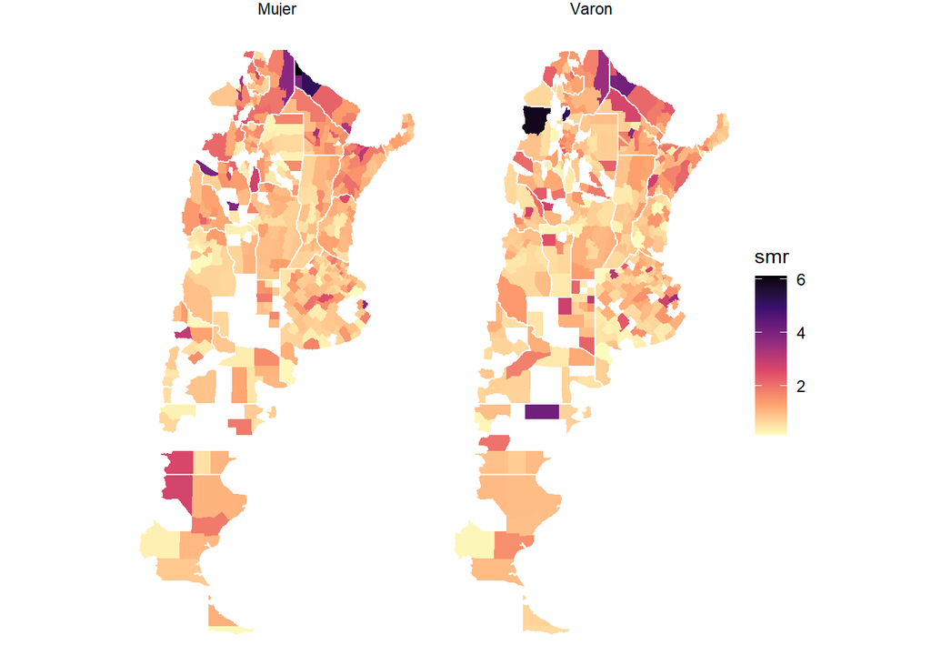

```r
geo_data_mort_estandar |>
  filter(gedad == "Menor de 24", grupo_oms=="Condiciones trans, m,p y n.", !is.na(smr)) |>
  ggplot(aes(fill=smr))+
  coord_sf(crs = 4326)+
  geom_sf(color=NA)+
  scale_fill_viridis_c(option = "magma", direction = -1)+
  geom_sf(data = geo_prov, fill=NA, lwd=.5, color="white")+
  facet_grid(~sexo,labeller = label_wrap_gen(multi_line = TRUE))+
  theme_void()
```

###### 1.12.2.1.2 No Transmisibles

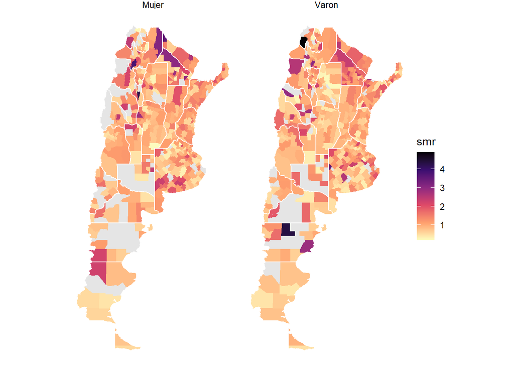

```r
geo_data_mort_estandar |>
  filter(gedad == "Menor de 24", grupo_oms=="Enfermedades no transmisibles") |>
  ggplot(aes(fill=smr))+
  coord_sf(crs = 4326)+
  geom_sf(color=NA)+
  scale_fill_viridis_c(option = "magma", direction = -1, na.value = "grey90")+
  geom_sf(data = geo_prov, fill=NA, lwd=.5, color="white")+
  facet_grid(~sexo,labeller = label_wrap_gen(multi_line = TRUE))+
  theme_void()
```

###### 1.12.2.1.3 Enfermedades mal definidas

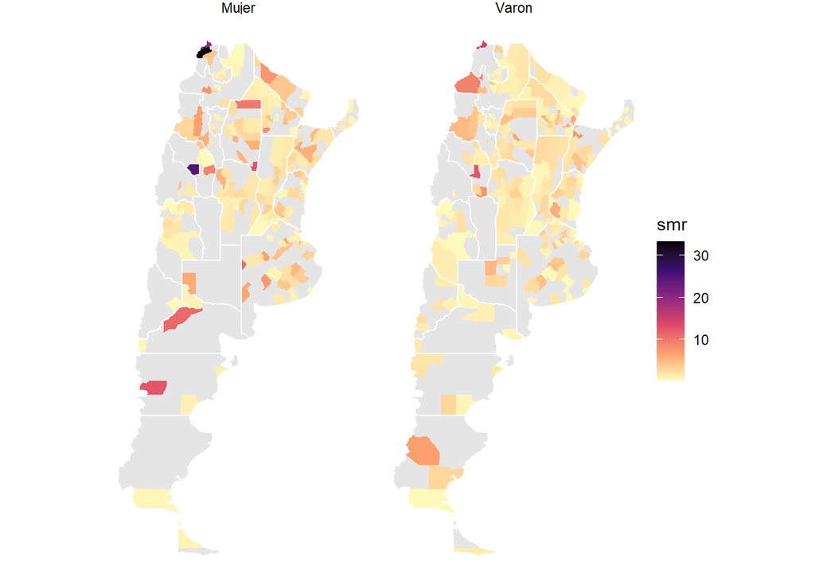

```r
geo_data_mort_estandar |>
  filter(gedad == "Menor de 24", grupo_oms=="Enfermedades mal definidas") |>
  ggplot(aes(fill=smr))+
  coord_sf(crs = 4326)+
  geom_sf(color=NA)+
  scale_fill_viridis_c(option = "magma", direction = -1, na.value = "grey90")+
  geom_sf(data = geo_prov, fill=NA, lwd=.5, color="white")+
  facet_grid(~sexo,labeller = label_wrap_gen(multi_line = TRUE))+
  theme_void()
```

###### 1.12.2.1.4 Lesiones

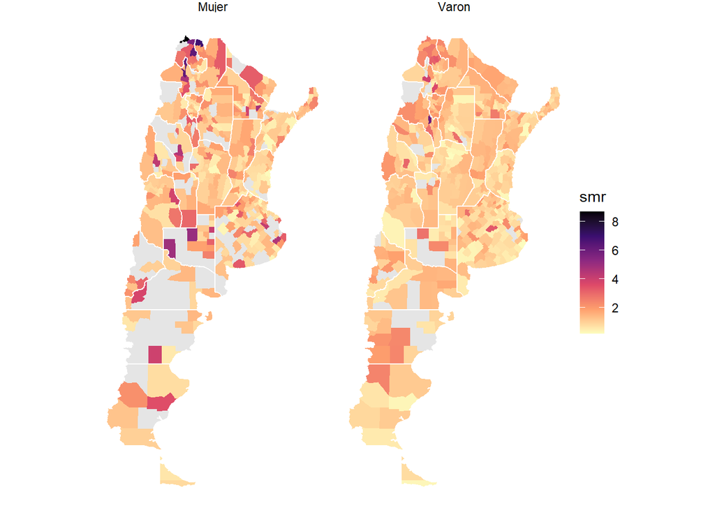

```r
geo_data_mort_estandar |>
  filter(gedad == "Menor de 24", grupo_oms=="Lesiones") |>
  ggplot(aes(fill=smr))+
  coord_sf(crs = 4326)+
  geom_sf(color=NA)+
  scale_fill_viridis_c(option = "magma", direction = -1, na.value = "grey90")+
  geom_sf(data = geo_prov, fill=NA, lwd=.5, color="white")+
  facet_grid(~sexo,labeller = label_wrap_gen(multi_line = TRUE))+
  theme_void()
```

##### 1.12.2.2 De 25 a 69

###### 1.12.2.2.1 Transmisibles

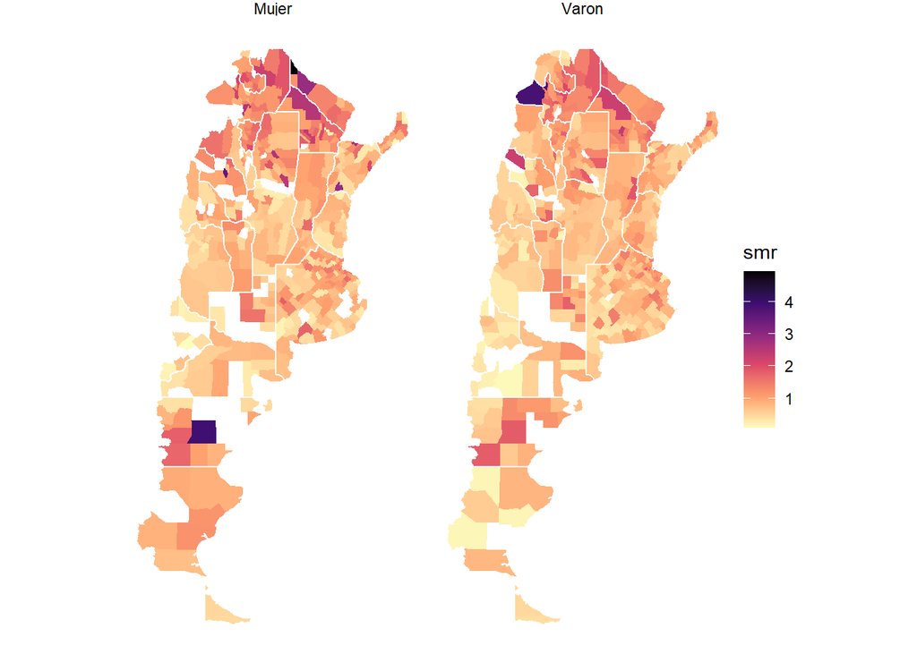

```r
geo_data_mort_estandar |>
  filter(gedad == "25 a 69", grupo_oms=="Condiciones trans, m,p y n.", !is.na(smr)) |>
  ggplot(aes(fill=smr))+
  coord_sf(crs = 4326)+
  geom_sf(color=NA)+
  scale_fill_viridis_c(option = "magma", direction = -1)+
  geom_sf(data = geo_prov, fill=NA, lwd=.5, color="white")+
  facet_grid(~sexo,labeller = label_wrap_gen(multi_line = TRUE))+
  theme_void()
```

###### 1.12.2.2.2 No Transmisibles

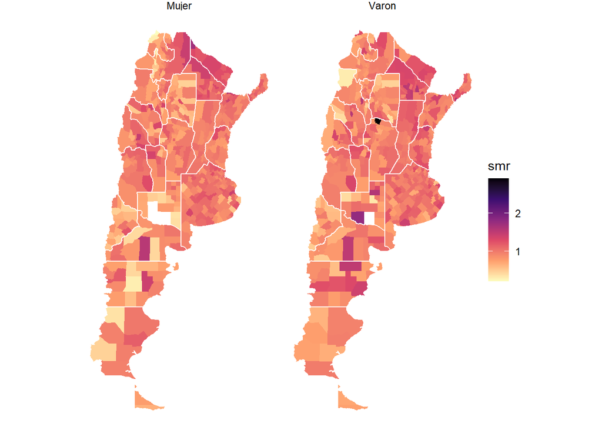

```r
geo_data_mort_estandar |>
  filter(gedad == "25 a 69", grupo_oms=="Enfermedades no transmisibles", !is.na(smr)) |>
  ggplot(aes(fill=smr))+
  coord_sf(crs = 4326)+
  geom_sf(color=NA)+
  scale_fill_viridis_c(option = "magma", direction = -1)+
  geom_sf(data = geo_prov, fill=NA, lwd=.5, color="white")+
  facet_grid(~sexo,labeller = label_wrap_gen(multi_line = TRUE))+
  theme_void()
```

###### 1.12.2.2.3 Mal definidas

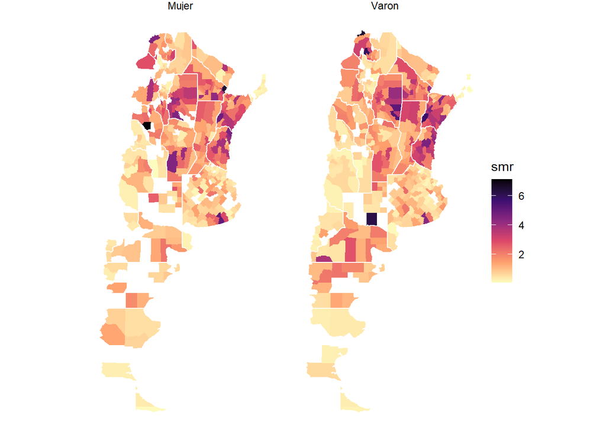

```r
geo_data_mort_estandar |>
  filter(gedad == "25 a 69", grupo_oms=="Enfermedades mal definidas", !is.na(smr)) |>
  ggplot(aes(fill=smr))+
  coord_sf(crs = 4326)+
  geom_sf(color=NA)+
  scale_fill_viridis_c(option = "magma", direction = -1)+
  geom_sf(data = geo_prov, fill=NA, lwd=.5, color="white")+
  facet_grid(~sexo,labeller = label_wrap_gen(multi_line = TRUE))+
  theme_void()
```

###### 1.12.2.2.4 Lesiones

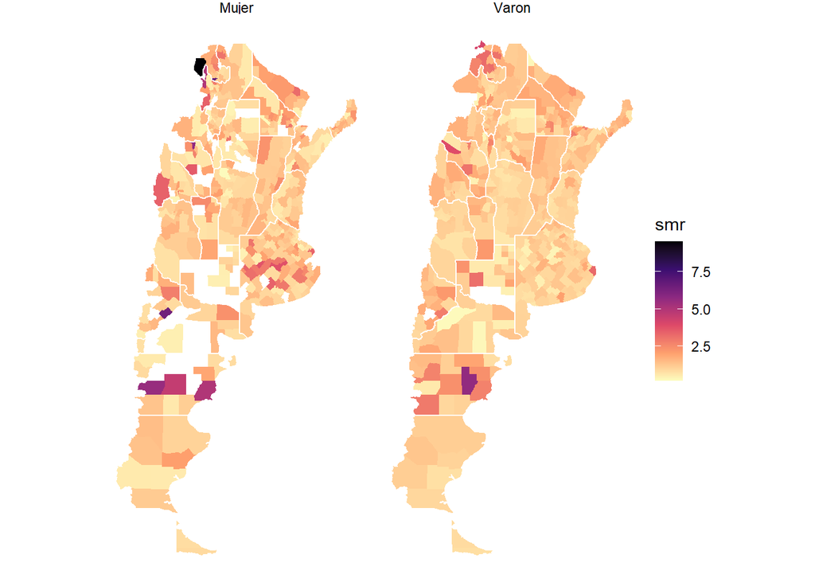

```r
geo_data_mort_estandar |>
  filter(gedad == "25 a 69", grupo_oms=="Lesiones", !is.na(smr)) |>
  ggplot(aes(fill=smr))+
  coord_sf(crs = 4326)+
  geom_sf(color=NA)+
  scale_fill_viridis_c(option = "magma", direction = -1)+
  geom_sf(data = geo_prov, fill=NA, lwd=.5, color="white")+
  facet_grid(~sexo,labeller = label_wrap_gen(multi_line = TRUE))+
  theme_void()
```

##### 1.12.2.3 De 70 y mas

###### 1.12.2.3.1 Transmisibles

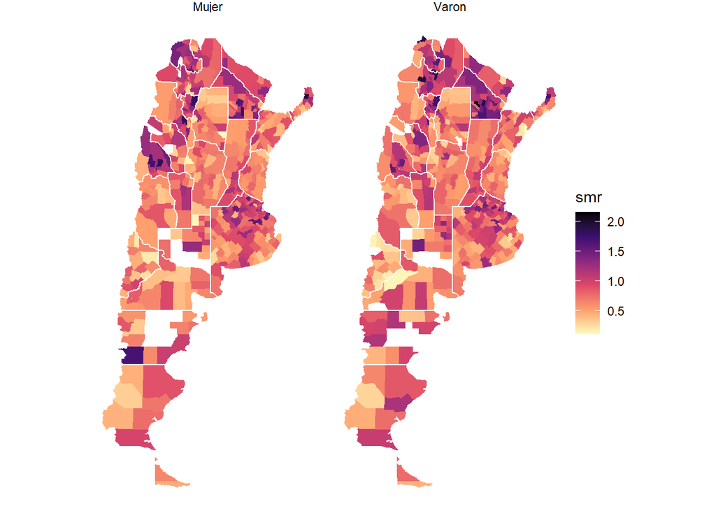

```r
geo_data_mort_estandar |>
  filter(gedad == "70 y mas", grupo_oms=="Condiciones trans, m,p y n.", !is.na(smr)) |>
  ggplot(aes(fill=smr))+
  coord_sf(crs = 4326)+
  geom_sf(color=NA)+
  scale_fill_viridis_c(option = "magma", direction = -1)+
  geom_sf(data = geo_prov, fill=NA, lwd=.5, color="white")+
  facet_grid(~sexo,labeller = label_wrap_gen(multi_line = TRUE))+
  theme_void()
```

###### 1.12.2.3.2 No Transmisibles

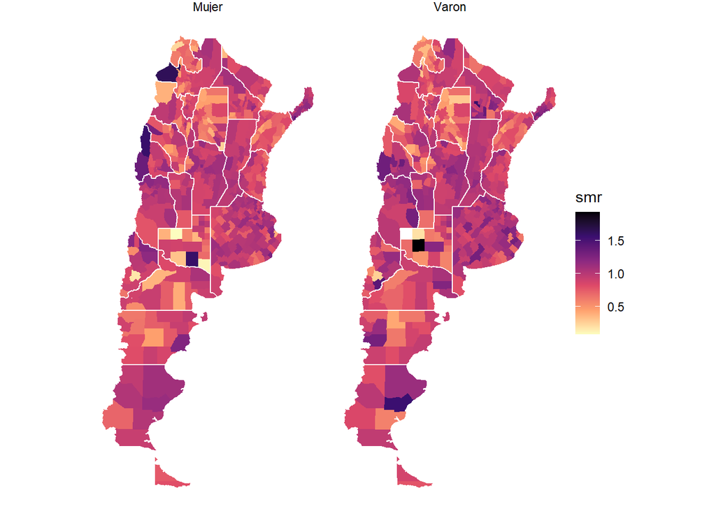

```r
geo_data_mort_estandar |>
  filter(gedad == "70 y mas", grupo_oms=="Enfermedades no transmisibles", !is.na(smr)) |>
  ggplot(aes(fill=smr))+
  coord_sf(crs = 4326)+
  geom_sf(color=NA)+
  scale_fill_viridis_c(option = "magma", direction = -1)+
  geom_sf(data = geo_prov, fill=NA, lwd=.5, color="white")+
  facet_grid(~sexo,labeller = label_wrap_gen(multi_line = TRUE))+
  theme_void()
```

###### 1.12.2.3.3 Mal definidas

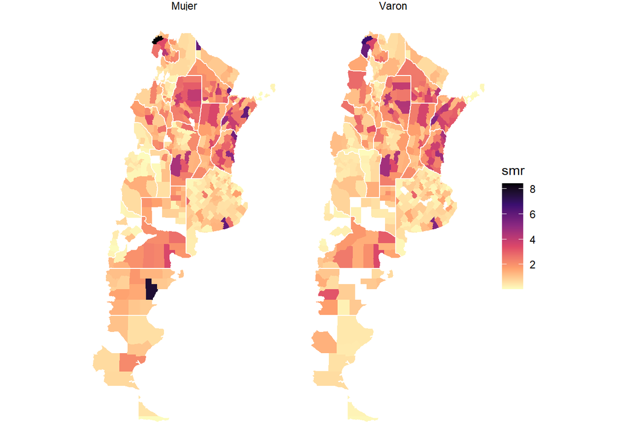

```r
geo_data_mort_estandar |>
  filter(gedad == "70 y mas", grupo_oms=="Enfermedades mal definidas", !is.na(smr)) |>
  ggplot(aes(fill=smr))+
  coord_sf(crs = 4326)+
  geom_sf(color=NA)+
  scale_fill_viridis_c(option = "magma", direction = -1)+
  geom_sf(data = geo_prov, fill=NA, lwd=.5, color="white")+
  facet_grid(~sexo,labeller = label_wrap_gen(multi_line = TRUE))+
  theme_void()
```

###### 1.12.2.3.4 Lesiones

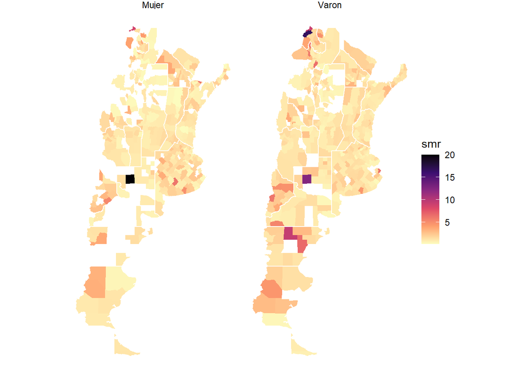

```r
geo_data_mort_estandar |>
  filter(gedad == "70 y mas", grupo_oms=="Lesiones", !is.na(smr)) |>
  ggplot(aes(fill=smr))+
  coord_sf(crs = 4326)+
  geom_sf(color=NA)+
  scale_fill_viridis_c(option = "magma", direction = -1)+
  geom_sf(data = geo_prov, fill=NA, lwd=.5, color="white")+
  facet_grid(~sexo,labeller = label_wrap_gen(multi_line = TRUE))+
  theme_void()
```

#### 1.12.3 Empirical Bayes

```r
vars_agg_local <- c("sexo", "gedad", "grupo_oms", "geocodigo")
```

Se prueba suavizar mediante prior total nacional y observar las diferencias

##### 1.12.3.1 Construccion de caso

###### 1.12.3.1.1 Mujeres jovenes Cond. Transmisibles

Enfermedades Transmisibles, maternas y perinatales y nutricionales, mujeres menores de 24

```r
unique(data_mort_estandar$grupo_oms)
```

```
## [1] "Enfermedades no transmisibles" "Condiciones trans, m,p y n."
## [3] "Enfermedades mal definidas"    "Lesiones"
```

```r
subset <- data_mort_estandar |>
  filter(
    gedad == "Menor de 24",
    anio == 2018,
    sexo == "Mujer",
    grupo_oms == "Condiciones trans, m,p y n."
  )
```

se crea un subset con Filtro de registros con eventos (casos > 0)

```r
subset |>
  filter(casos>0)->subset
```

Suavizado

```r
subset_smooth <- SpatialEpi::eBayes(
  subset$casos,
  subset$pob
)
```

Vista del resultado

```r
glimpse(subset_smooth)
```

```
## List of 5
##  $ RR   : num [1:430] 0.001453 0.001197 0.001079 0.000743 0.000782 ...
##  $ RRmed: num [1:430] 0.001438 0.001181 0.001064 0.000724 0.000764 ...
##  $ beta : Named num -7.26
##   ..- attr(*, "names")= chr "(Intercept)"
##  $ alpha: num 11.9
##  $ SMR  : num [1:430] 0.00401 0.00339 0.00259 0.00258 0.00253 ...
```

Se agregan las columnas como campos calculados

```r
subset$rr <- subset_smooth$RR
subset$rrmed <- subset_smooth$RRmed
subset$smr_bayes <- subset_smooth$SMR
```

Comparacion

```r
summary(subset$rm_loc)
##      Min.   1st Qu.    Median      Mean   3rd Qu.      Max.
## 0.0001165 0.0004899 0.0006608 0.0007631 0.0009239 0.0040104
summary(subset$rm)
##      Min.   1st Qu.    Median      Mean   3rd Qu.      Max.
## 0.0006557 0.0006557 0.0006557 0.0006557 0.0006557 0.0006557
summary(subset$smr)
##    Min. 1st Qu.  Median    Mean 3rd Qu.    Max.
##   0.180   0.750   1.010   1.164   1.407   6.120
summary(subset$rr)
##      Min.   1st Qu.    Median      Mean   3rd Qu.      Max.
## 0.0003458 0.0006324 0.0006918 0.0007008 0.0007542 0.0014527
summary(subset$rrmed)
##      Min.   1st Qu.    Median      Mean   3rd Qu.      Max.
## 0.0003424 0.0006193 0.0006771 0.0006884 0.0007378 0.0014376
summary(subset$smr_bayes)
##      Min.   1st Qu.    Median      Mean   3rd Qu.      Max.
## 0.0001165 0.0004899 0.0006608 0.0007631 0.0009239 0.0040104
```

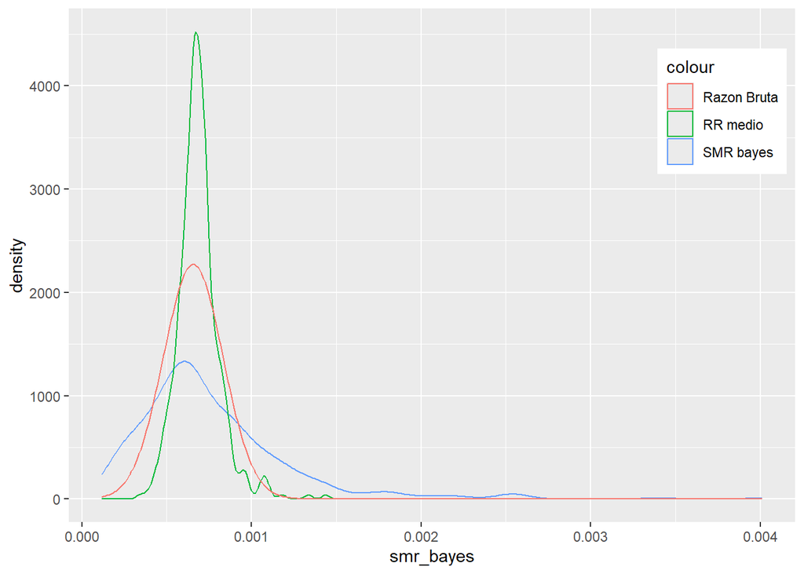

```r
subset |>
  ggplot()+
  geom_density(aes(smr_bayes, color="SMR bayes"))+
  geom_density(aes(rrmed, color= "RR medio"))+
  geom_density(aes(rm, colour = "Razon Bruta"))+
  theme(
    legend.position = "inside",
    legend.position.inside = c(.9, .8)
  )
```

1.12.3.1.1.1 Suavizado local

Se utiliza el subset creado para 2018

```r
head(subset)
```

```
## # A tibble: 6 × 15
##   gedad       sexo  geocodigo label   anio grupo_oms casos   pob      rm  rm_loc
##   <ord>       <chr> <chr>     <chr>  <dbl> <chr>     <int> <dbl>   <dbl>   <dbl>
## 1 Menor de 24 Mujer 34063     Ramón…  2018 Condicio…    20  4987 6.56e-4 0.00401
## 2 Menor de 24 Mujer 34007     Berme…  2018 Condicio…    13  3830 6.56e-4 0.00339
## 3 Menor de 24 Mujer 34028     Matac…  2018 Condicio…    11  4245 6.56e-4 0.00259
## 4 Menor de 24 Mujer 46077     Gener…  2018 Condicio…     1   387 6.56e-4 0.00258
## 5 Menor de 24 Mujer 46070     Gener…  2018 Condicio…     2   792 6.56e-4 0.00253
## 6 Menor de 24 Mujer 6812      Tordi…  2018 Condicio…     1   398 6.56e-4 0.00251
## # ℹ 5 more variables: casos_esp <dbl>, smr <dbl>, rr <dbl>, rrmed <dbl>,
## #   smr_bayes <dbl>
```

```r
class(subset)
```

```
## [1] "tbl_df"     "tbl"        "data.frame"
```

Con el subset creado, de mortalidad de mujeres menores de 24 por Enfermedades transmisibles, maternas y perinatales, hacemos las pruebas de suavizado.

```r
probmap_subset <- spdep::probmap(
  n = subset$casos, x = subset$pob,
  row.names = subset$geocodigo,
  alternative = "greater"
)
```

Se obtiene la razon o tasa bruta, las defunciones esperadas, el riesgo relativo o SMR * 100, y la Probabilidad = pmap.

```r
head(probmap_subset)
```

```
##               raw  expCount  relRisk         pmap
## 34063 0.004010427 3.3196803 602.4677 4.657351e-10
## 34007 0.003394256 2.5495038 509.9031 2.940079e-06
## 34028 0.002591284 2.8257556 389.2764 1.769465e-04
## 46077 0.002583979 0.2576131 388.1791 2.271058e-01
## 46070 0.002525253 0.5272081 379.3568 9.856452e-02
## 6812  0.002512563 0.2649354 377.4505 2.327445e-01
```

Se agregan las nuevas columnas

```r
subset$rm_loc2 <- probmap_subset$raw
subset$casos_exp <- probmap_subset$expCount
subset$rr <- probmap_subset$relRisk / 100
subset$pmap <- probmap_subset$pmap
```

#### 1.12.4 Mapa

Union con geometria vectorial.

```r
subset |>
  merge(geo_depto, by.x = "geocodigo", by.y = "DEPTO_LINK")-> geo_subset
geo_subset <- st_as_sf(geo_subset)
```

Se representan 2 mapas, a la izquierda el SMR y a la derecha el umbral de probabilidad.

```r
geo_subset |>
  ggplot(aes(fill=smr))+
  geom_sf(color=NA)+
  scale_fill_viridis_c(option = "magma", direction = -1)+
  geom_sf(data = geo_prov, fill=NA, lwd=.5, color="white")+
  labs(
    title="SMR"
  )+
  theme_void()-> mapa_smr_m24

geo_subset |>
  ggplot(aes(fill=pmap))+
  geom_sf(color=NA)+
  scale_fill_viridis_c(option = "D" , direction = -1)+
  geom_sf(data = geo_prov, fill=NA, lwd=.5, color="white")+
  labs(
    title = "Prob"
  )+
  theme_void()-> mapa_pmap_m24
```

```r
library(patchwork)
```

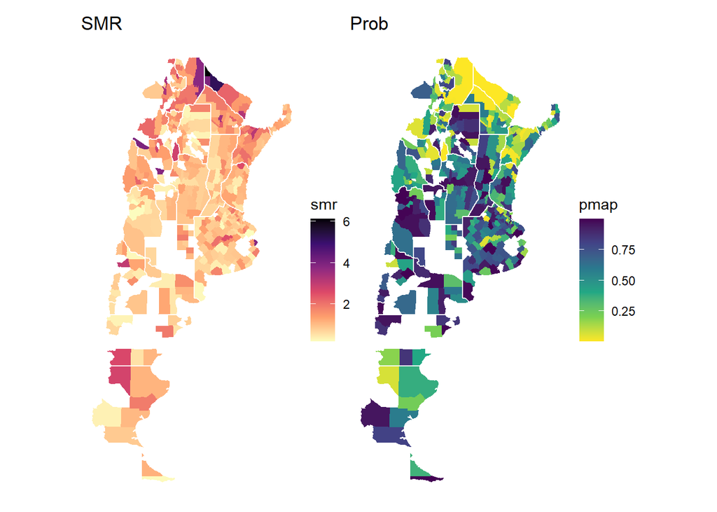

```r
mapa_smr_m24 | mapa_pmap_m24
```

##### 1.12.4.1 Area de interes

Detectar areas de interes.

```r
prob <- geo_subset |>
  mutate(
    pmap.prob = ifelse(rr > 1 & pmap < 0.05,
                       1,
                       0)
    ) |>
  group_by(pmap.prob) |>
  summarise() |>
  filter(pmap.prob == 1)
```

Se seleccionan aquellas areas con SMR mayor que uno (sobre mortalidad) y una probabilidad (umbral) menor a 0.05.

```r
head(prob)
```

```
## Simple feature collection with 1 feature and 1 field
## Geometry type: MULTIPOLYGON
## Dimension:     XY
## Bounding box:  xmin: -68.7123 ymin: -34.81094 xmax: -54.15138 ymax: -21.99618
## Geodetic CRS:  WGS 84
## # A tibble: 1 × 2
##   pmap.prob                                                                 geom
##       <dbl>                                                   <MULTIPOLYGON [°]>
## 1         1 (((-58.25157 -31.70952, -58.24899 -31.71328, -58.24692 -31.7147, -5…
```

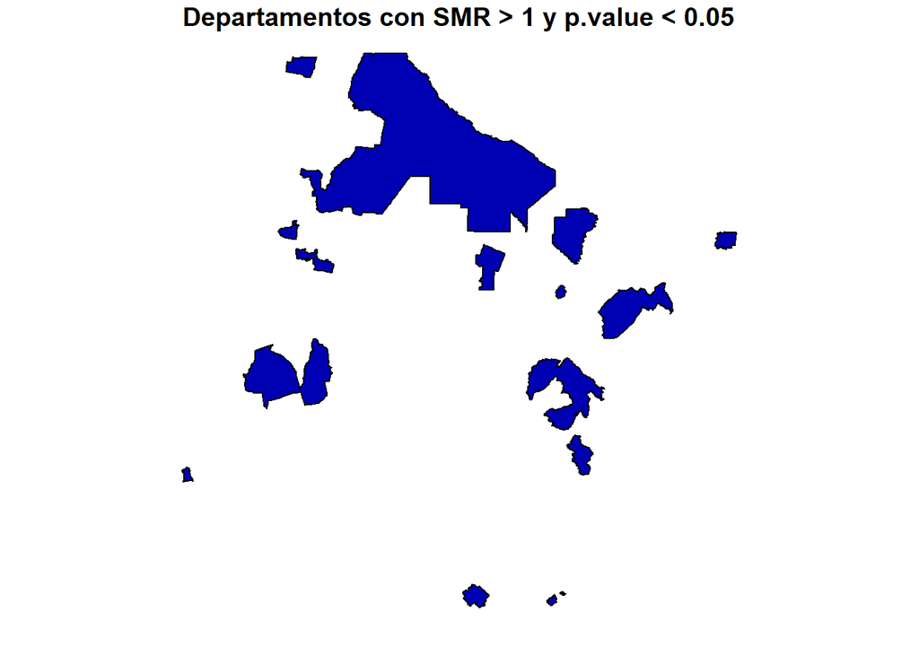

```r
plot(prob, main = "Departamentos con SMR > 1 y p.value < 0.05")
```

Se resalta el cluster de sobremortalidad sobre el mapa original de SMR

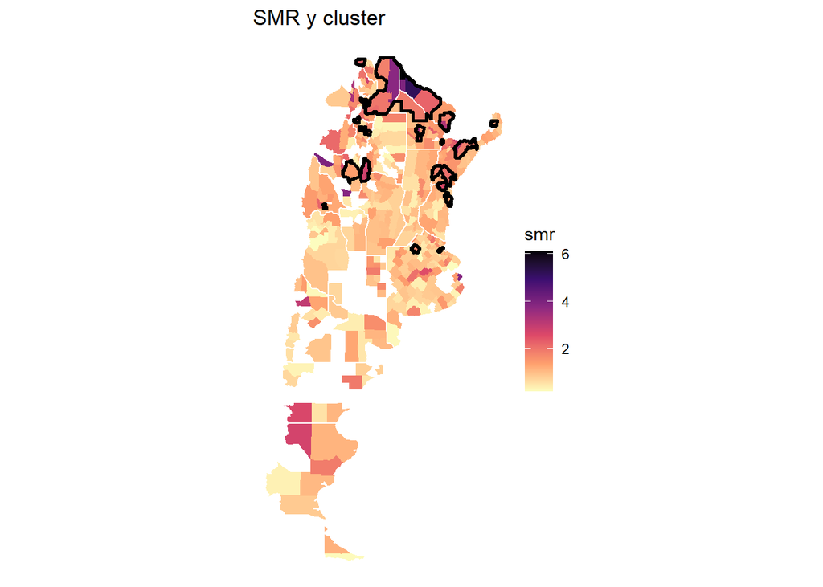

```r
geo_subset |>
  ggplot()+
  geom_sf(data = geo_subset, aes(fill=smr), color=NA)+
  scale_fill_viridis_c(option = "magma", direction = -1)+
  geom_sf(data = geo_prov, fill=NA, lwd=.5, color="white" )+
  geom_sf(data = prob, color="black",lwd=1, alpha=0)+
  coord_sf(crs = 4326)+
  labs(
    title= "SMR y cluster"
  )+
  theme_void()
```

###### 1.12.4.1.1 Bayes espacial

Se puede crear una matriz de vecindad

```r
nb <- spdep::poly2nb(geo_subset, queen = TRUE, row.names = geo_subset$geocodigo)
summary(nb)
```

```
## Neighbour list object:
## Number of regions: 430
## Number of nonzero links: 2098
## Percentage nonzero weights: 1.134667
## Average number of links: 4.87907
## 1 region with no links:
## 62091
## 5 disjoint connected subgraphs
## Link number distribution:
##
##  0  1  2  3  4  5  6  7  8  9 10 11
##  1  7 32 57 86 93 82 42 15 10  4  1
## 7 least connected regions:
## 26035 42070 58007 58077 6420 94007 94014 with 1 link
## 1 most connected region:
## 30049 with 11 links
```

Por alguna razon el departamento `62091` no tiene vecinos.

```r
nb_gal <- spdep::read.gal("data_geo/shp_depto/deptos.gal", geo_depto$DEPTO_LINK)
summary(nb_gal)
```

```
## Neighbour list object:
## Number of regions: 511
## Number of nonzero links: 8872
## Percentage nonzero weights: 3.397659
## Average number of links: 17.36204
## 2 disjoint connected subgraphs
## Link number distribution:
##
##  1  4  5  6  7  8  9 10 11 12 13 14 15 16 17 18 19 20 21 22 23 24 25 26 27 28
##  2  2  4  5  6  9 15 14 23 22 30 29 35 32 28 40 43 31 34 21 19 15  9  5 13  8
## 29 30 31 32 33 34 36 37
##  2  7  1  2  1  2  1  1
## 2 least connected regions:
## 94014 94007 with 1 link
## 1 most connected region:
## 14175 with 37 links
```

```r
centroids <- st_centroid(st_geometry(geo_depto))
```

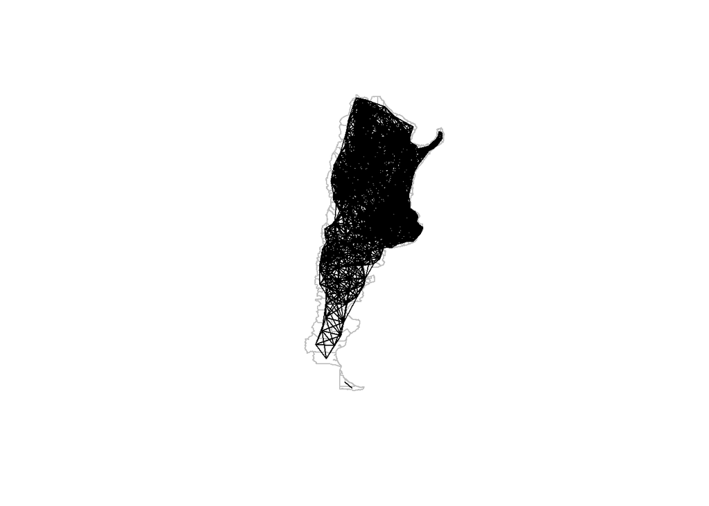

```r
plot(st_geometry(geo_depto), border = 'grey')
spdep::plot.nb(nb_gal, centroids, points = F, add = T)
```

```r
geo_data_mort_estandar |>
  filter(anio == 2018,
         gedad == "Menor de 24",
         sexo == "Mujer",
         grupo_oms == "Condiciones trans, m,p y n."
         ) |>
  select(geocodigo, casos, casos_esp, pob, rm_loc, smr)-> geo_data_subset
```

```r
head(geo_data_subset)
```

```
## Simple feature collection with 6 features and 6 fields
## Geometry type: MULTIPOLYGON
## Dimension:     XY
## Bounding box:  xmin: -68.66476 ymin: -29.74428 xmax: -65.27595 ymax: -25.15006
## Geodetic CRS:  WGS 84
##   geocodigo casos casos_esp  pob       rm_loc  smr
## 1     10007     0      0.57  863 0.0000000000   NA
## 2     10014     0      0.39  594 0.0000000000   NA
## 3     10021     1      2.58 3933 0.0002542588 0.39
## 4     10028     0      0.21  321 0.0000000000   NA
## 5     10035     5      4.18 6381 0.0007835762 1.20
## 6     10042     1      2.60 3967 0.0002520797 0.38
##                             geom
## 1 MULTIPOLYGON (((-65.86416 -...
## 2 MULTIPOLYGON (((-65.48914 -...
## 3 MULTIPOLYGON (((-66.29727 -...
## 4 MULTIPOLYGON (((-66.9848 -2...
## 5 MULTIPOLYGON (((-67.23803 -...
## 6 MULTIPOLYGON (((-66.13648 -...
```

1.12.4.1.1.1 Bayesiano empirico

Modelos bayesiano empirico, con dependencia espacial

```r
library(spdep)
eb_subset <- EBlocal(
  ri = geo_data_subset$casos,
  ni = geo_data_subset$pob,
  nb = nb_gal,
  zero.policy = TRUE
)
```

```r
str(eb_subset)
```

```
## 'data.frame':    511 obs. of  2 variables:
##  $ raw: num  0 0 0.000254 0 0.000784 ...
##  $ est: num  0.000819 0.000614 0.00054 0.000639 0.000674 ...
##  - attr(*, "parameters")=List of 2
##   ..$ a: num [1:511] 3.90e-08 1.29e-08 7.49e-09 7.84e-09 0.00 ...
##   ..$ m: num [1:511] 0.000851 0.000621 0.000555 0.000642 0.000674 ...
```

```r
geo_data_subset$raw <- eb_subset$raw
geo_data_subset$est <- eb_subset$est
```

```r
ggplot()+
  geom_sf(data = geo_data_subset, aes(fill=est), color=NA)+
  scale_fill_viridis_c(option = "magma", direction = -1)+
  geom_sf(data = geo_prov, fill=NA, lwd=.5, color="white")+
  coord_sf(crs = 4326)+
  labs(
    title = "Suavizado Bayes empirico",
    fill="RM suavizado"
  )+
  theme_void()-> mapa_eb_m24
```

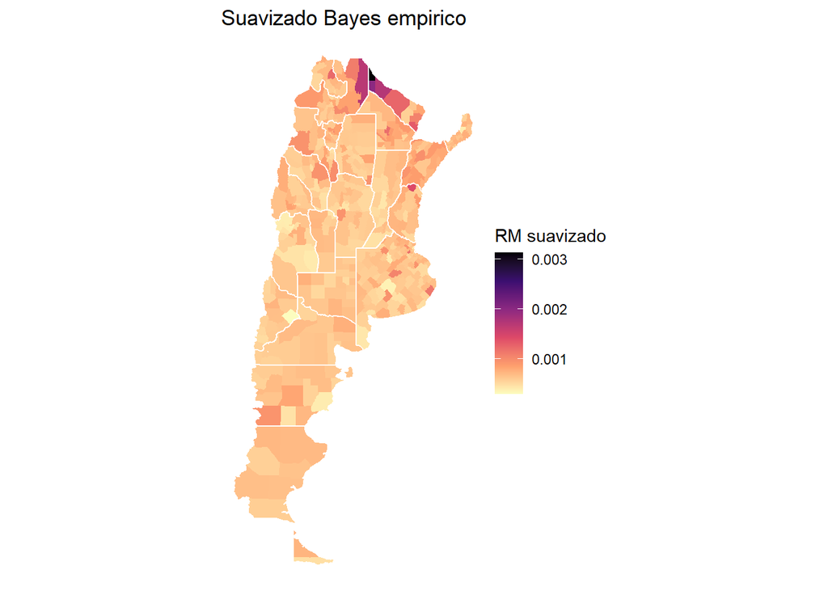

```r
mapa_eb_m24
```

Comparacion con la razon bruta.

```r
geo_data_mort_estandar |>
  filter(gedad == "Menor de 24",
         grupo_oms=="Condiciones trans, m,p y n.",
         sexo == "Mujer") |>
  ggplot(aes(fill=rm_loc))+
  coord_sf(crs = 4326)+
  geom_sf(color=NA)+
  scale_fill_viridis_c(option = "magma", direction = -1)+
  geom_sf(data = geo_prov, fill=NA, lwd=.5, color="white")+
  labs(
    title="Rm cruda"
  )+
  theme_void() -> mapa_raw_m24
```

[output not shown]

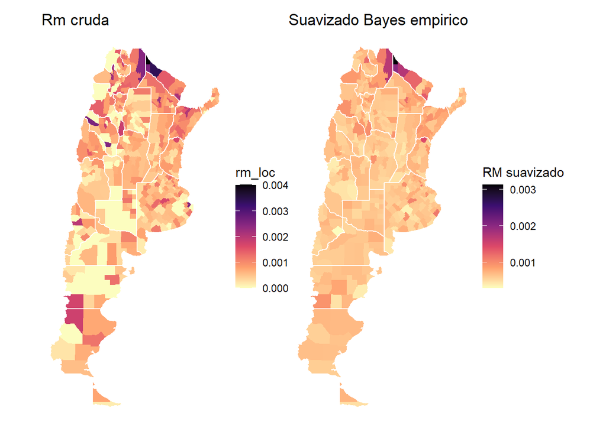

```r
mapa_raw_m24 | mapa_eb_m24
```

#### 1.12.5 Bayes espacial 2

El ejemplo anterior muestra que con el suavizamiento , o “estrechamiento” de la distribucion (“shrunk”) funciono como se esperaba para diferenciar ruido de señal. Es decir, se desestimaron en el analisis ciertas areas, y el mapa final muestra las areas de sobremortalidad. Aunque esto era previsible dadas las grandes diferencias en el patron de mortalidad en este grupo de edad y causa.  
En adelante se pone a prueba el mismo procedimiento pero para una distribucion por causas mas aplanada, y sin grandes diferencias evidentes.

Mortalidad de varones en edades centrales 25 a 69 por Enfermedades no transmisibles.

```r
subset2 <- data_mort_estandar |>
  filter(
    gedad == "25 a 69",
    anio == 2018,
    sexo == "Varon",
    grupo_oms == "Enfermedades no transmisibles"
  )
```

probabilidad de exceso de mortalidad

```r
probmap_subset2 <- spdep::probmap(
  n = subset2$casos, x = subset2$pob,
  row.names = subset2$geocodigo,
  alternative = "greater"
)
```

```r
head(probmap_subset2)
```

```
##              raw  expCount  relRisk         pmap
## 14154 0.03598326 14.722808 292.0639 1.671196e-09
## 42042 0.02197802  4.484604 178.3881 8.532386e-02
## 54035 0.01985878 27.917893 161.1869 1.777356e-03
## 42035 0.01953995 49.811140 158.5991 8.221978e-05
## 22119 0.01951220 37.885050 158.3738 5.497998e-04
## 46126 0.01923077  8.969208 156.0896 7.231023e-02
```

```r
subset2$rm_loc2 <- probmap_subset2$raw
subset2$casos_exp <- probmap_subset2$expCount
subset2$rr <- probmap_subset2$relRisk / 100
subset2$pmap <- probmap_subset2$pmap
```

```r
subset2 |>
  merge(geo_depto, by.x = "geocodigo", by.y = "DEPTO_LINK")-> geo_subset2
geo_subset2 <- st_as_sf(geo_subset2)
```

Mapas

```r
geo_subset2 |>
  ggplot(aes(fill=smr))+
  geom_sf(color=NA)+
  scale_fill_viridis_c(option = "magma", direction = -1)+
  geom_sf(data = geo_prov, fill=NA, lwd=.5, color="white")+
  labs(
    title="SMR"
  )+
  theme_void()-> mapa_smr_v25

geo_subset2 |>
  ggplot(aes(fill=pmap))+
  geom_sf(color=NA)+
  scale_fill_viridis_c(option = "D" , direction = -1)+
  geom_sf(data = geo_prov, fill=NA, lwd=.5, color="white")+
  labs(
    title = "Prob"
  )+
  theme_void()-> mapa_pmap_v25
```

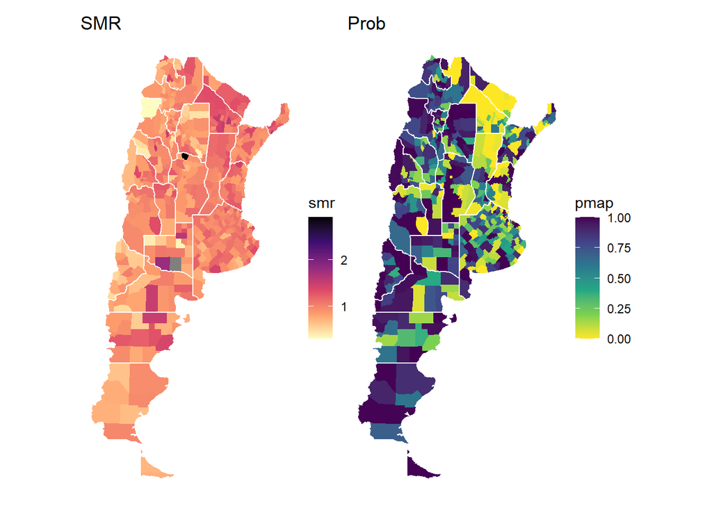

```r
mapa_smr_v25 | mapa_pmap_v25
```